# Code for longitudinal SBP and SHT analysis in cats

C Pye

2026-06-18

#This R markdown file contains code used to examine changes in SBP and hypertension risk in 209 cats enrolled on CatPAWS. final edit to accompany manuscript

#1. Load libraries

```r
library(lme4)
```

```r
library("ggplot2")
library(splines)
library(dplyr)
library(sjPlot)
library(tidyverse)
library(mclogit)
library(performance)
library(gtsummary)
library(ggfortify)
library(ggridges)
library(patchwork)
library(see)
library(geepack)
library("survival")
library("ggsurvfit")
library("gee")
library("car")
library(boot)
library(rms)
```

#2. load data

```r
Metadata_209_cats<-read.csv("Metadata_hypertension.csv")
```

#3. order factors in df

#4. create dataframe removing SBP NA

```r
Metadata_SBP<-Metadata_209_cats%>%
  filter(!is.na(Metadata_209_cats$SBP))

##remove rows from cats recieving antihypertensives

#8 rows with cats receiving amlodipine
amlodipine_cases<-Metadata_SBP[c(226, 227, 228, 229, 293, 601, 623, 842),]
print(amlodipine_cases)
```

```
##     Cat_ID_timepoint Cat_ID Owner_ID timepoint       date        dob Age_years
## 226         Cat038_4 Cat038   Own031       4.0 12/10/2021 05/10/2007  14.02053
## 227       Cat038_4.5 Cat038   Own031       4.5 10/05/2022 05/10/2007  14.59548
## 228         Cat038_5 Cat038   Own031       5.0 22/11/2022 05/10/2007  15.13210
## 229       Cat038_5.5 Cat038   Own031       5.5 23/05/2023 05/10/2007  15.63039
## 293         Cat045_6 Cat045   Own037       6.0 10/07/2023 08/04/2009  14.25325
## 601       Cat092_5.5 Cat092   Own075       5.5 27/09/2023 20/02/2009  14.59822
## 623       Cat094_5.5 Cat094   Own075       5.5 27/09/2023 01/02/2009  14.65024
## 842       Cat140_4.5 Cat140   Own110       4.5 20/10/2023 01/09/2011  12.13415
##            Breed   breed    Sex neuter_status weight BCS MCS_combined
## 226 Non-pedigree     DMH   Male           Yes   4.40   4           NA
## 227 Non-pedigree     DMH   Male           Yes   4.19   4           13
## 228 Non-pedigree     DMH   Male           Yes   4.19   4           17
## 229 Non-pedigree     DMH   Male           Yes   4.34   4           13
## 293 Non-pedigree     DSH   Male           Yes   6.12   7           20
```

[output cut: 66 more lines]

```r
#8 visits from 5 cats in total.

#remove these from SBP data

Metadata_SBP2<-Metadata_SBP[c(-226, -227, -228, -229, -293, -601, -623, -842),]

#write csv

#write.csv(Metadata_SBP2, "Metadata_SBP2.csv")
```

#5. summarise data

##a. no.of visits and no.of cats

```
## [1] 1116   40
```

```
## # A tibble: 203 × 2
##    Cat_ID `n_distinct(Cat_ID)`
##    <chr>                 <int>
##  1 Cat001                    1
##  2 Cat002                    1
##  3 Cat003                    1
##  4 Cat004                    1
##  5 Cat005                    1
##  6 Cat006                    1
##  7 Cat007                    1
##  8 Cat008                    1
##  9 Cat009                    1
## 10 Cat010                    1
## # ℹ 193 more rows
```

##b. summarise age data

```r
# Function to summarise age stats
summarise_age <- function(data, group_var) {
  data %>%
    group_by({{ group_var }}) %>%
    summarise(
      N = n_distinct(Cat_ID),  # use your unique cat ID column
      Median_Age = round(median(Age_years, na.rm = TRUE), 1),
      IQR_Age = paste0(round(quantile(Age_years, 0.25, na.rm = TRUE), 1), "–",
                       round(quantile(Age_years, 0.75, na.rm = TRUE), 1)),
      Age_Range = paste0(round(min(Age_years, na.rm = TRUE), 1), "–",
                         round(max(Age_years, na.rm = TRUE), 1)),
      .groups = "drop"
    )
}

# Summary tables
summarise_age(Metadata_SBP2)
```

```
## # A tibble: 1 × 4
##       N Median_Age IQR_Age  Age_Range
##   <int>      <dbl> <chr>    <chr>
## 1   203       10.3 8.8–11.9 6.7–16.4
```

```r
age_by_sex <- summarise_age(Metadata_SBP2, Sex)

age_by_health <- summarise_age(Metadata_SBP2, Overall_health_status)

age_by_breed <- summarise_age(Metadata_SBP2, Breed)

# Combine for full table (optional)
full_age_summary <- bind_rows(
  age_by_sex %>% mutate(Group = paste0("Sex: ", Sex)) %>% select(Group, everything(), -Sex),
  age_by_health %>% mutate(Group = paste0("Health: ", Overall_health_status)) %>% select(Group, everything(), -Overall_health_status),
  age_by_breed %>% mutate(Group = paste0("Breed: ", Breed)) %>% select(Group, everything(), -Breed)
)

# View full summary
print(full_age_summary)
```

```
## # A tibble: 6 × 5
##   Group                   N Median_Age IQR_Age  Age_Range
##   <chr>               <int>      <dbl> <chr>    <chr>
## 1 Sex: Female           106       10.2 8.8–11.9 6.7–16
## 2 Sex: Male              97       10.3 9–11.9   6.9–16.4
## 3 Health: Healthy        69        9.5 8.2–10.8 6.9–15.4
## 4 Health: Not_Healthy   134       10.5 9.1–12.2 6.7–16.4
## 5 Breed: Non-pedigree   175       10.4 9–12     6.7–16.4
## 6 Breed: Pedigree        28        9.7 8.4–11.5 7–15.5
```

```r
# Summary tables for SBP

age_by_sex <- summarise_age(Metadata_SBP2, Sex)

age_by_health <- summarise_age(Metadata_SBP2, Overall_health_status)

age_by_breed <- summarise_age(Metadata_SBP2, Breed)

# Combine for full table (optional)
full_age_summary <- bind_rows(
  age_by_sex %>% mutate(Group = paste0("Sex: ", Sex)) %>% select(Group, everything(), -Sex),
  age_by_health %>% mutate(Group = paste0("Health: ", Overall_health_status)) %>% select(Group, everything(), -Overall_health_status),
  age_by_breed %>% mutate(Group = paste0("Breed: ", Breed)) %>% select(Group, everything(), -Breed)
)

# View full summary
print(full_age_summary)
```

```
## # A tibble: 6 × 5
##   Group                   N Median_Age IQR_Age  Age_Range
##   <chr>               <int>      <dbl> <chr>    <chr>
## 1 Sex: Female           106       10.2 8.8–11.9 6.7–16
## 2 Sex: Male              97       10.3 9–11.9   6.9–16.4
## 3 Health: Healthy        69        9.5 8.2–10.8 6.9–15.4
## 4 Health: Not_Healthy   134       10.5 9.1–12.2 6.7–16.4
## 5 Breed: Non-pedigree   175       10.4 9–12     6.7–16.4
## 6 Breed: Pedigree        28        9.7 8.4–11.5 7–15.5
```

```r
# Combine for full table (optional)
full_age_summary <- bind_rows(
  age_by_sex %>% mutate(Group = paste0("Sex: ", Sex)) %>% select(Group, everything(), -Sex),
  age_by_health %>% mutate(Group = paste0("Health: ", Overall_health_status)) %>% select(Group, everything(), -Overall_health_status),
  age_by_breed %>% mutate(Group = paste0("Breed: ", Breed)) %>% select(Group, everything(), -Breed)
)

# View full summary
print(full_age_summary)
```

```
## # A tibble: 6 × 5
##   Group                   N Median_Age IQR_Age  Age_Range
##   <chr>               <int>      <dbl> <chr>    <chr>
## 1 Sex: Female           106       10.2 8.8–11.9 6.7–16
## 2 Sex: Male              97       10.3 9–11.9   6.9–16.4
## 3 Health: Healthy        69        9.5 8.2–10.8 6.9–15.4
## 4 Health: Not_Healthy   134       10.5 9.1–12.2 6.7–16.4
## 5 Breed: Non-pedigree   175       10.4 9–12     6.7–16.4
## 6 Breed: Pedigree        28        9.7 8.4–11.5 7–15.5
```

##c. ridge plots

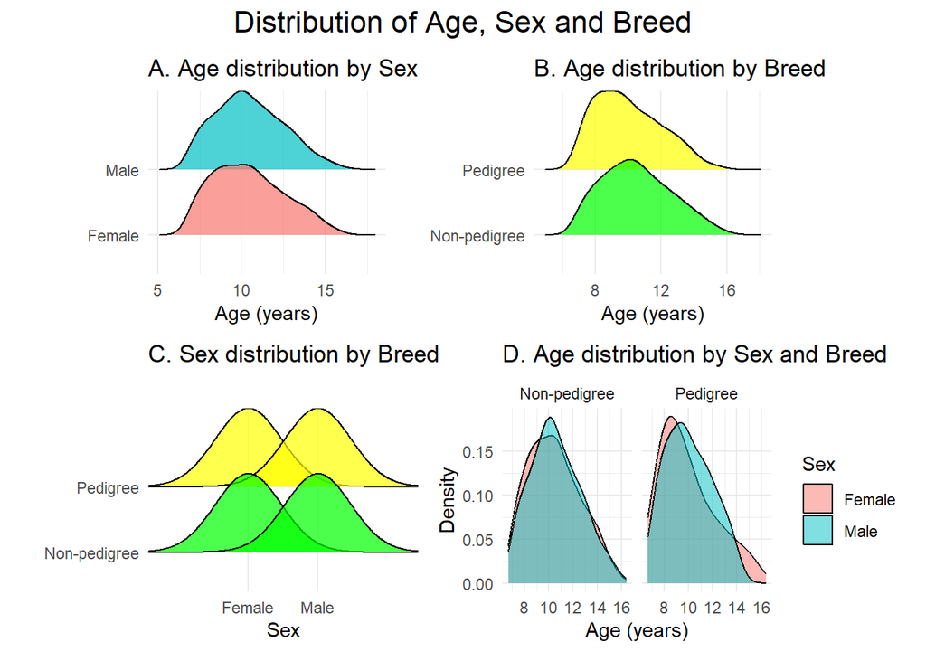

```r
# Plot A: Age by Sex
pA <- ggplot(Metadata_SBP2, aes(x = Age_years, y = Sex, fill = Sex)) +
  geom_density_ridges(alpha = 0.7, scale = 1.2) +
  theme_minimal() +
  labs(title = "A. Age distribution by Sex", x = "Age (years)", y = "") +
  theme(legend.position = "none")

# Plot B: Age by Breed
pB <- ggplot(Metadata_SBP2, aes(x = Age_years, y = Breed, fill = Breed)) +
  geom_density_ridges(alpha = 0.7, scale = 1.2) +
  scale_fill_manual(values=c("Pedigree" = "yellow", "Non-pedigree" = "green"))+
  theme_minimal() +
  labs(title = "B. Age distribution by Breed", x = "Age (years)", y = "") +
  theme(legend.position = "none")

# Plot C: Age by Health Status
#pC <- ggplot(Metadata_SBP2, aes(x = Age_years, y = #Overall_health_status, fill = Overall_health_status)) +
#  geom_density_ridges(alpha = 0.7, scale = 1.2) +
#  theme_minimal() +
#  labs(title = "C. Age distribution by Overall Health Status", #x = "Age (years)", y = "") +
#  theme(legend.position = "none")

# Plot C: Sex by Breed
pC <- ggplot(Metadata_SBP2, aes(x = Sex, y = Breed, fill = Breed)) +
  geom_density_ridges(alpha = 0.7, scale = 1.2) +
  scale_fill_manual(values=c("Pedigree" = "yellow", "Non-pedigree" = "green"))+
  theme_minimal() +
  labs(title = "C. Sex distribution by Breed", x = "Sex", y = "") +
  theme(legend.position = "none")

# Plot D: Age by Sex and Breed
pD <- ggplot(Metadata_SBP2, aes(x = Age_years, fill = Sex)) +
  geom_density(alpha = 0.5) +
  facet_wrap(~ Breed) +
  theme_minimal() +
  labs(title = "D. Age distribution by Sex and Breed", x = "Age (years)", y = "Density")

# Plot F: Age by Sex and Health Status
pF <- ggplot(Metadata_SBP2, aes(x = Age_years, fill = Sex)) +
  geom_density(alpha = 0.5) +
  facet_wrap(~ Overall_health_status) +
  theme_minimal() +
  labs(title = "F. Age distribution by Sex and Health Status", x = "Age (years)", y = "Density")

# Plot G: Age by Breed and Health Status
pG<-ggplot(Metadata_SBP2, aes(x = Age_years, fill = Breed)) +
  geom_density(alpha = 0.5) +
  facet_wrap(~ Overall_health_status) +
  theme_minimal() +
  labs(title = "G. Age Distribution by Breed and Health Status",
       x = "Age (years)", y = "Density")

# Combine using patchwork
(pA + pB) / (pC+ pD) +
  plot_annotation(title = "Distribution of Age, Sex and Breed",
                  theme = theme(plot.title = element_text(hjust = 0.5, size = 16)))
```

```r
#ggsave("Supplementary_Figure_DistributionPlots2.png", #width = 12, height = 12, dpi = 300)
```

#6. Analysis of SBP

##a. Summarise data

```r
# Count the number of visits with sbpdata
num_visits_with_SBP <- Metadata_SBP2 %>%
  filter(!is.na(SBP)) %>%
  summarise(num_visits = n())

# Count the number of cats with sbp data
num_cats_with_SBP <- Metadata_SBP2 %>%
  filter(!is.na(SBP)) %>%
  summarise(num_cats = n_distinct(Cat_ID))

# Print the results
print(num_visits_with_SBP)
```

```
##   num_visits
## 1       1116
```

```r
print(num_cats_with_SBP)
```

```
##   num_cats
## 1      203
```

```r
# Count the number of visits per cat with sbp data
visits_per_cat <- Metadata_SBP2 %>%
  filter(!is.na(SBP)) %>%
  group_by(Cat_ID) %>%
  summarise(num_visits = n())

# Calculate median, IQR, and range
median_visits <- median(visits_per_cat$num_visits)
iqr_visits <- IQR(visits_per_cat$num_visits)
q1 <- quantile(visits_per_cat$num_visits, 0.25)  # First quartile (Q1)
q3 <- quantile(visits_per_cat$num_visits, 0.75)  # Third quartile (Q3)
range_visits <- range(visits_per_cat$num_visits)  # Returns min and max

# Print the results
print(median_visits)
```

```
## [1] 5
```

```r
print(iqr_visits)
```

```
## [1] 6
```

```r
print(q1)
```

```
## 25%
##   2
```

```r
print(q3)
```

```
## 75%
##   8
```

```r
print(range_visits)
```

```
## [1]  1 12
```

##b. Is the SBP data normal?

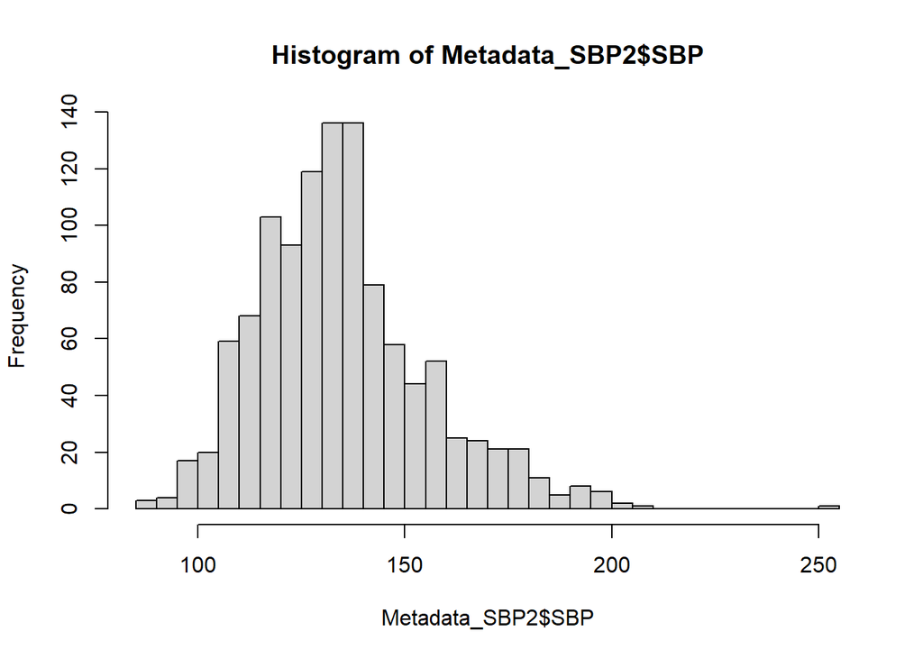

```r
hist(Metadata_SBP2$SBP, breaks=50)
```

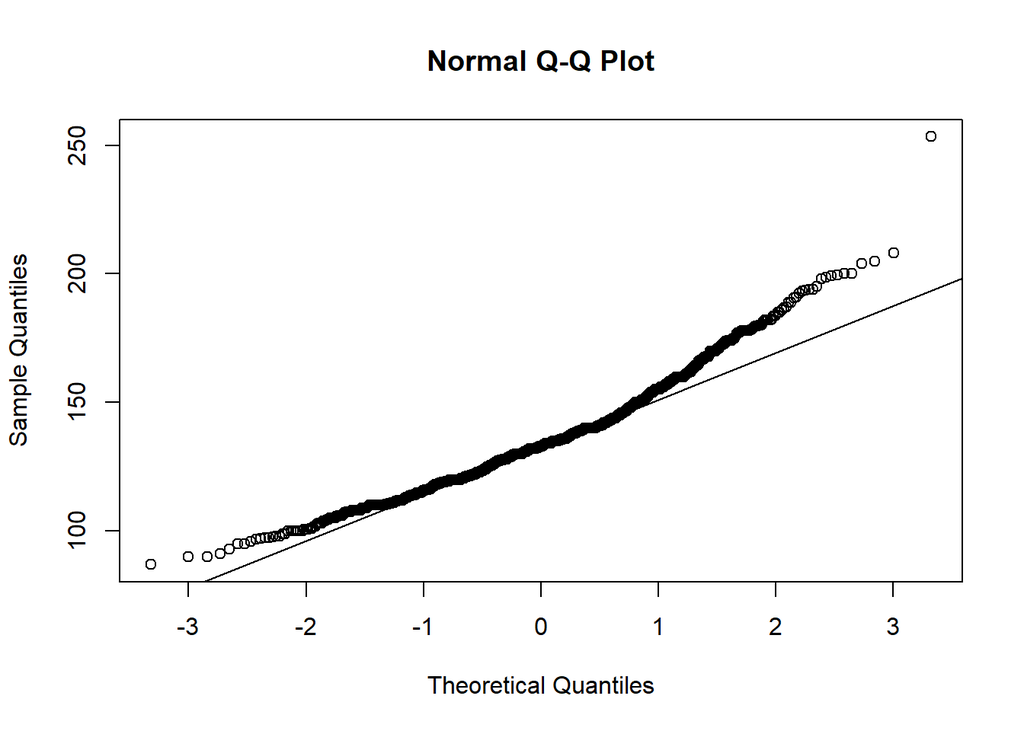

```r
qqnorm(Metadata_SBP2$SBP)
qqline(Metadata_SBP2$SBP)
```

```r
shapiro.test(Metadata_SBP2$SBP)
```

```
##
##  Shapiro-Wilk normality test
##
## data:  Metadata_SBP2$SBP
## W = 0.9632, p-value = 3.504e-16
```

```r
##data is not normal
```

##c. describe age at baseline (e.g. first SBP measured) ###i. create df of baseline data

```r
#create dataset of baseline data

Metadata_SBP2_baseline<-Metadata_SBP2 %>%
  arrange(Cat_ID, date) %>%
  group_by(Cat_ID) %>%
  slice(1) %>%
  ungroup()
```

###ii. check normality

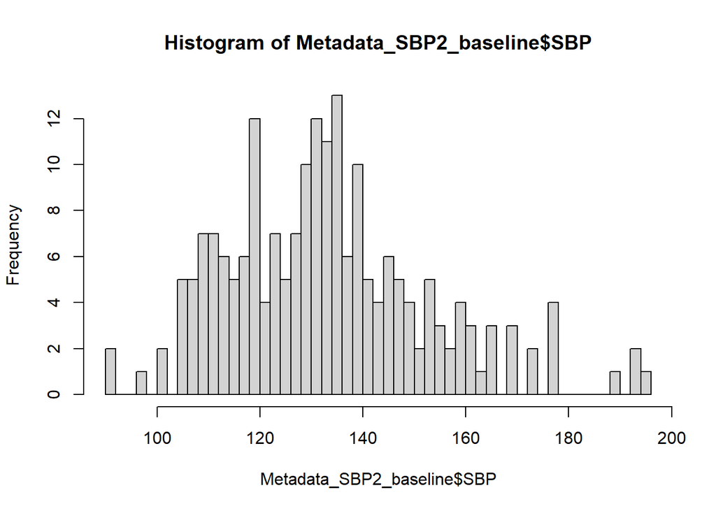

```r
#is it normal?
hist(Metadata_SBP2_baseline$SBP, breaks=50)
```

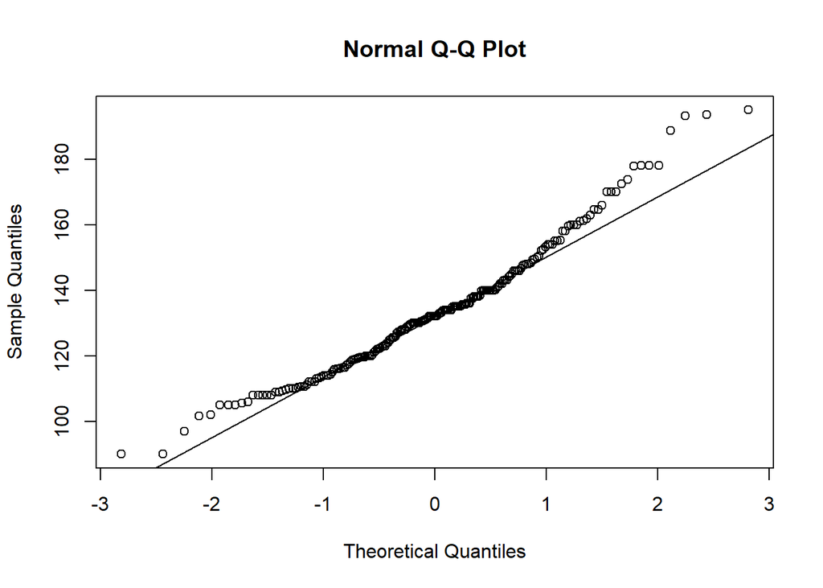

```r
qqnorm(Metadata_SBP2_baseline$SBP)
qqline(Metadata_SBP2_baseline$SBP)
```

```r
shapiro.test(Metadata_SBP2_baseline$SBP)
```

```
##
##  Shapiro-Wilk normality test
##
## data:  Metadata_SBP2_baseline$SBP
## W = 0.9699, p-value = 0.0002432
```

```r
#not normal
```

###iii.summarise baseline data

```r
#summarise age
summarise_age(Metadata_SBP2_baseline)
```

```
## # A tibble: 1 × 4
##       N Median_Age IQR_Age  Age_Range
##   <int>      <dbl> <chr>    <chr>
## 1   203        9.8 8.4–11.1 6.7–15.3
```

```r
#average years follow up per cat
# Calculate follow-up duration per cat
followup_per_cat <- Metadata_SBP2 %>%
  group_by(Cat_ID) %>%
  summarise(
    followup_years = max(Age_years, na.rm = TRUE) - min(Age_years, na.rm = TRUE)
  )

print(followup_per_cat)
```

```
## # A tibble: 203 × 2
##    Cat_ID followup_years
##    <chr>           <dbl>
##  1 Cat001           3.93
##  2 Cat002           6.88
##  3 Cat003           0
##  4 Cat004           0
##  5 Cat005           5.65
##  6 Cat006           2.61
##  7 Cat007           4.66
##  8 Cat008           6.19
##  9 Cat009           0
## 10 Cat010           0
## # ℹ 193 more rows
```

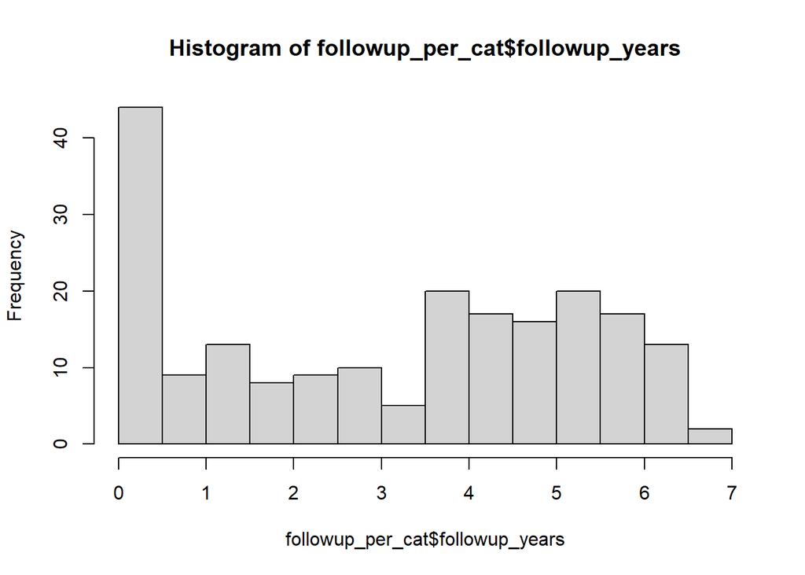

```r
hist(followup_per_cat$followup_years, breaks=10)
```

```r
shapiro.test(followup_per_cat$followup_years)
```

```
##
##  Shapiro-Wilk normality test
##
## data:  followup_per_cat$followup_years
## W = 0.90923, p-value = 8.201e-10
```

```r
#not normal - median IQR range
# Calculate average follow-up duration across all cats
median_followup <- median(followup_per_cat$followup_years, na.rm = TRUE)
Q1_followup<- quantile(followup_per_cat$followup_years, 0.25)
Q3_followup<- quantile(followup_per_cat$followup_years, 0.75)
min_followup<- min(followup_per_cat$followup_years)
max_followup<- max(followup_per_cat$followup_years)

# Print results
print(followup_per_cat)       # follow-up per cat
```

```
## # A tibble: 203 × 2
##    Cat_ID followup_years
##    <chr>           <dbl>
##  1 Cat001           3.93
##  2 Cat002           6.88
##  3 Cat003           0
##  4 Cat004           0
##  5 Cat005           5.65
##  6 Cat006           2.61
##  7 Cat007           4.66
##  8 Cat008           6.19
##  9 Cat009           0
## 10 Cat010           0
## # ℹ 193 more rows
```

```r
cat("Median follow-up time (years):", median_followup, "\n")
```

```
## Median follow-up time (years): 3.526352
```

```r
cat("Q1 follow-up time (years):", Q1_followup, "\n")
```

```
## Q1 follow-up time (years): 0.973306
```

```r
cat("Q3 follow-up time (years):", Q3_followup, "\n")
```

```
## Q3 follow-up time (years): 5.037645
```

```r
cat("min follow-up time (years):", min_followup, "\n")
```

```
## min follow-up time (years): 0
```

```r
cat("max follow-up time (years):", max_followup, "\n")
```

```
## max follow-up time (years): 6.880219
```

```r
median(Metadata_SBP2_baseline$SBP, na.rm=T)
```

```
## [1] 132
```

```r
range(Metadata_SBP2_baseline$SBP, na.rm=T)
```

```
## [1]  90 195
```

```r
IQR(Metadata_SBP2_baseline$SBP, na.rm=T)
```

```
## [1] 24.8
```

```r
quantile(Metadata_SBP2_baseline$SBP, 0.25, na.rm=T)
```

```
##    25%
## 119.45
```

```r
quantile(Metadata_SBP2_baseline$SBP, 0.75, na.rm=T)
```

```
##    75%
## 144.25
```

```r
median(Metadata_SBP2_baseline$weight, na.rm=T)
```

```
## [1] 4.7
```

```r
range(Metadata_SBP2_baseline$weight, na.rm=T)
```

```
## [1] 2.40 9.18
```

```r
IQR(Metadata_SBP2_baseline$weight, na.rm=T)
```

```
## [1] 1.545
```

```r
quantile(Metadata_SBP2_baseline$weight, 0.25, na.rm=T)
```

```
##   25%
## 3.845
```

```r
quantile(Metadata_SBP2_baseline$weight, 0.75, na.rm=T)
```

```
##  75%
## 5.39
```

```r
median(Metadata_SBP2_baseline$BCS, na.rm=T)
```

```
## [1] 6
```

```r
range(Metadata_SBP2_baseline$BCS, na.rm=T)
```

```
## [1] 2 9
```

```r
IQR(Metadata_SBP2_baseline$BCS, na.rm=T)
```

```
## [1] 2
```

```r
quantile(Metadata_SBP2_baseline$BCS, 0.25, na.rm=T)
```

```
## 25%
##   5
```

```r
quantile(Metadata_SBP2_baseline$BCS, 0.75, na.rm=T)
```

```
## 75%
##   7
```

```r
median(Metadata_SBP2_baseline$MCS_combined, na.rm=T)
```

```
## [1] 30
```

```r
range(Metadata_SBP2_baseline$MCS_combined, na.rm=T)
```

```
## [1] 10 30
```

```r
IQR(Metadata_SBP2_baseline$MCS_combined, na.rm=T)
```

```
## [1] 5
```

```r
quantile(Metadata_SBP2_baseline$MCS_combined, 0.25, na.rm=T)
```

```
## 25%
##  25
```

```r
quantile(Metadata_SBP2_baseline$MCS_combined, 0.75, na.rm=T)
```

```
## 75%
##  30
```

```r
#breed
sum(Metadata_SBP2_baseline$Breed=="Pedigree")
```

```
## [1] 28
```

```r
sum(Metadata_SBP2_baseline$Breed!="Pedigree")
```

```
## [1] 175
```

```r
Metadata_SBP2_baseline%>%
  group_by(breed)%>%
  summarise(N=n())
```

```
## # A tibble: 17 × 2
##    breed                  N
##    <chr>              <int>
##  1 American Exotic        2
##  2 Balinese               1
##  3 Bengal                 3
##  4 British short hair     3
##  5 DLH                   21
##  6 DMH                   24
##  7 DSH                  130
##  8 Egyptian Mau           1
##  9 Maine coon             1
## 10 Ocicat                 1
## 11 Oriental               2
## 12 Persian                4
## 13 Ragdoll                4
## 14 Russian blue           1
## 15 Siamese                3
## 16 Somali                 1
## 17 Sphynx                 1
```

```r
#sex
sum(Metadata_SBP2_baseline$Sex=="Male")
```

```
## [1] 97
```

```r
sum(Metadata_SBP2_baseline$Sex=="Female")
```

```
## [1] 106
```

```r
#neuter
sum(Metadata_SBP2_baseline$neuter_status=="No")
```

```
## [1] 2
```

```r
#morbidities at baseline
sum(Metadata_SBP2_baseline$CKD=="Yes")
```

```
## [1] NA
```

```r
sum(Metadata_SBP2_baseline$Hypertension=="Yes")
```

```
## [1] 21
```

```r
sum(Metadata_SBP2_baseline$Diabetes_mellitus=="Yes")
```

```
## [1] 2
```

```r
sum(Metadata_SBP2_baseline$Hyperthyroidism=="Yes")
```

```
## [1] 11
```

```r
sum(Metadata_SBP2_baseline$oe.abnormalities_Yes_no_incomplete=="Yes", na.rm=TRUE)
```

```
## [1] 103
```

```r
sum(Metadata_SBP2_baseline$Dental_disease=="Yes")
```

```
## [1] NA
```

```r
sum(Metadata_SBP2_baseline$Neoplasia=="Yes")
```

```
## [1] NA
```

```r
sum(Metadata_SBP2_baseline$FIV.Y.N=="Yes")
```

```
## [1] 0
```

```r
sum(Metadata_SBP2_baseline$Heart_murmur=="Yes")
```

```
## [1] 60
```

```r
#morbidities by study end
sum(Metadata_SBP2_baseline$CKD_over.study=="Yes", na.rm=T)
```

```
## [1] 23
```

```r
sum(Metadata_SBP2_baseline$hypertensive_over.study=="Yes")
```

```
## [1] 41
```

```r
sum(Metadata_SBP2_baseline$Diabetes_mellitus=="Yes")
```

```
## [1] 2
```

```r
sum(Metadata_SBP2_baseline$hyperthyroid_over.study=="Yes")
```

```
## [1] 18
```

```r
sum(Metadata_SBP2_baseline$oe_abnormalities_over_study=="1")
```

```
## [1] 172
```

```r
sum(Metadata_SBP2_baseline$dental_dz_over_study=="1")
```

```
## [1] 172
```

```r
sum(Metadata_SBP2_baseline$neoplasia_over.study=="Yes")
```

```
## [1] 18
```

```r
sum(Metadata_SBP2_baseline$HM_at_least_once=="Yes")
```

```
## [1] 124
```

##d. plot changes in spahetti plot to see SBP

###i. code for themed plots

```r
My_Theme = theme(
  axis.title.x = element_text(size = 16),
  axis.text.x = element_text(size = 14),
  axis.text.y = element_text(size=14),
  axis.title.y = element_text(size = 16),
 plot.title = element_text(size = 16, hjust = 0.5))
```

###ii. ## age overall

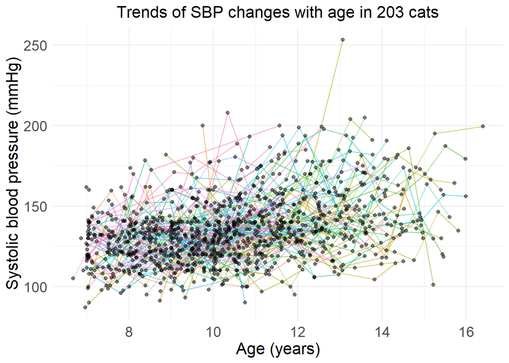

```r
g<-ggplot(Metadata_SBP2, aes(x = Age_years, y = SBP, group = Cat_ID)) +
  geom_line(aes(group=factor(Cat_ID), col=Cat_ID, alpha = 0.5)) +  # Add lines connecting data points for each cat
  geom_point(alpha = 0.5) +  # Add points for each data point
  labs(x = "Age (years)", y = "Systolic blood pressure (mmHg)", title = "Trends of SBP changes with age in 203 cats") +
  theme_minimal() +
  theme(legend.position="none")

g +My_Theme
```

```r
#ggsave("Trends of SBP changes with age in 203 cats.png", #plot= last_plot(), bg = "white", height = 2100, width = #3150, units="px" )
```

###iii. sex

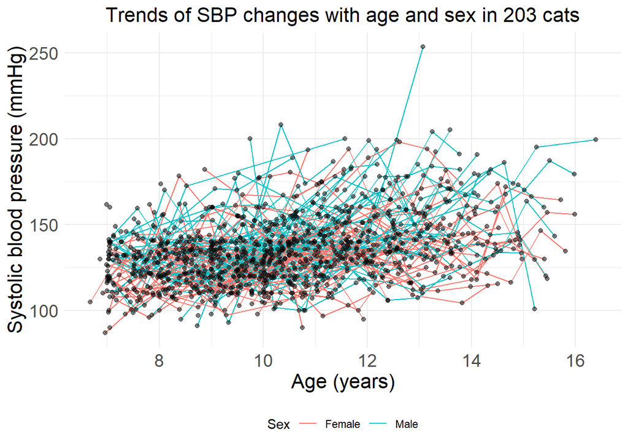

```r
g2<-ggplot(Metadata_SBP2, aes(x = Age_years, y = SBP, group = Cat_ID)) +
  geom_line(aes(group=factor(Cat_ID), col=Sex)) +  # Add lines connecting data points for each cat
  geom_point(alpha = 0.5) +  # Add points for each data point
  labs(x = "Age (years)", y = "Systolic blood pressure (mmHg)", title = "Trends of SBP changes with age and sex in 203 cats") +
  theme_minimal() +
  theme(legend.position="bottom")

g2 +My_Theme
```

```r
#ggsave("Trends of SBP changes with age in 203 cats by #sex.png", plot= last_plot(), bg = "white", height = #2100, width = 3150, units="px" )
```

###iv. facet by Cat_ID

[output not shown]

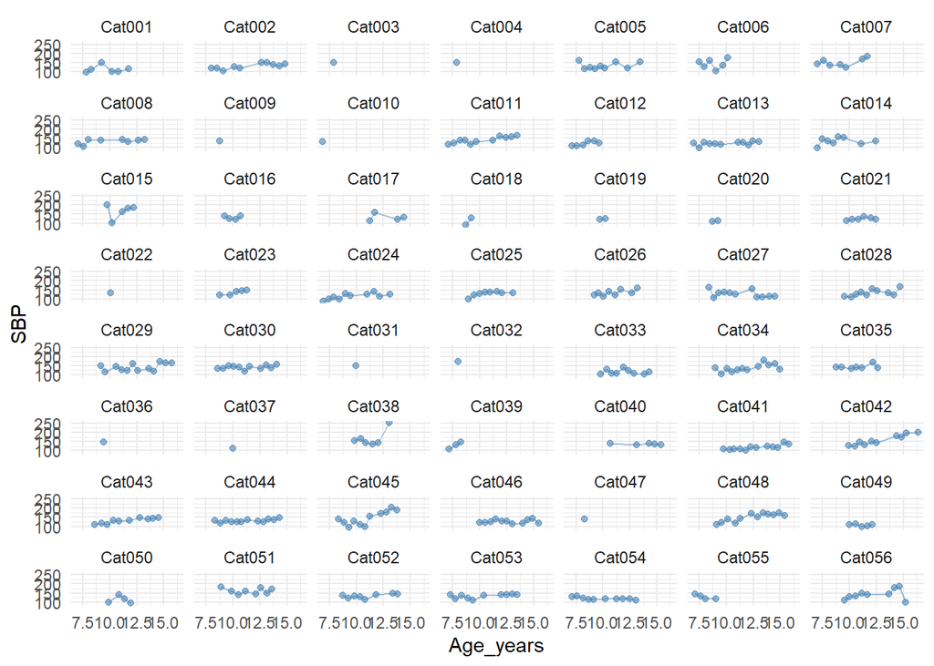

```r
# Split dataframe
cat_ids <- unique(Metadata_SBP2$Cat_ID)

first  <- cat_ids[1:56]
second <- cat_ids[57:112]
third <- cat_ids[113:168]
fourth<- cat_ids[169:203]

ggplot(filter(Metadata_SBP2, Cat_ID %in% first),
             aes(Age_years, SBP, group = Cat_ID)) +
  facet_wrap(~ Cat_ID, ncol = 7) +
  geom_line(alpha = 0.5, colour = "steelblue") +
  geom_point(alpha = 0.6, colour = "steelblue") +
  theme_minimal() +
  theme(legend.position = "none")
```

[output not shown]

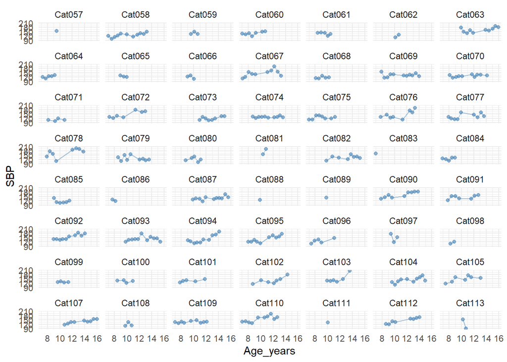

```r
ggplot(filter(Metadata_SBP2, Cat_ID %in% second),
             aes(Age_years, SBP, group = Cat_ID)) +
  facet_wrap(~ Cat_ID, ncol = 7) +
  geom_line(alpha = 0.5, colour = "steelblue") +
  geom_point(alpha = 0.6, colour = "steelblue") +
  theme_minimal() +
  theme(legend.position = "none")
```

[output not shown]

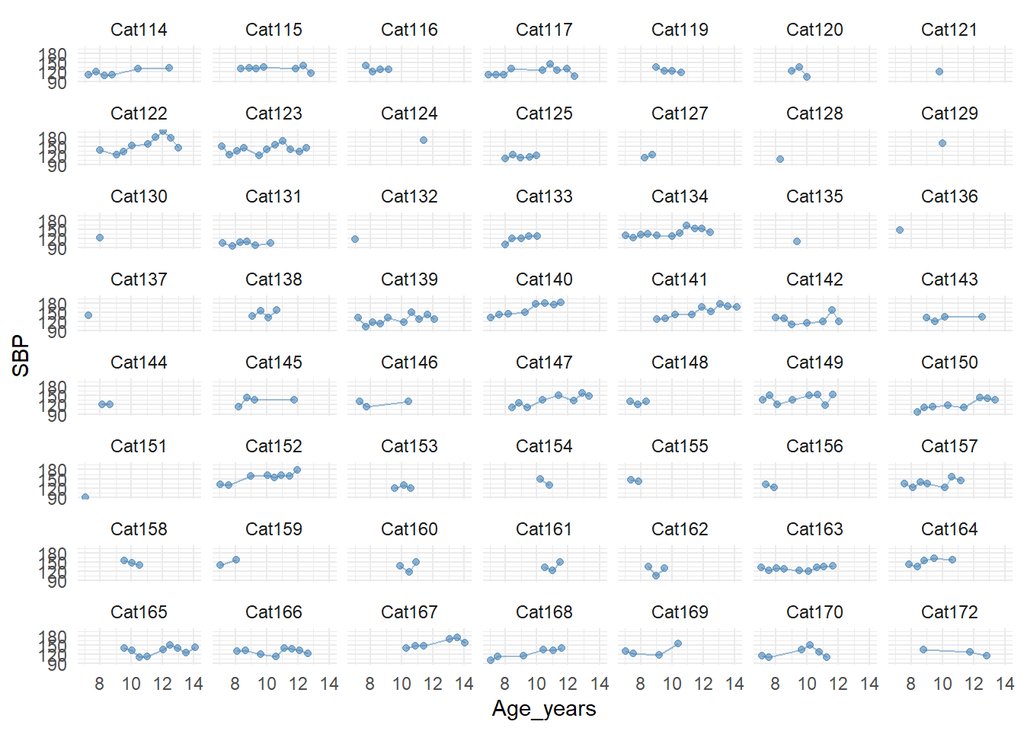

```r
ggplot(filter(Metadata_SBP2, Cat_ID %in% third),
             aes(Age_years, SBP, group = Cat_ID)) +
  facet_wrap(~ Cat_ID, ncol = 7) +
  geom_line(alpha = 0.5, colour = "steelblue") +
  geom_point(alpha = 0.6, colour = "steelblue") +
  theme_minimal() +
  theme(legend.position = "none")
```

[output not shown]

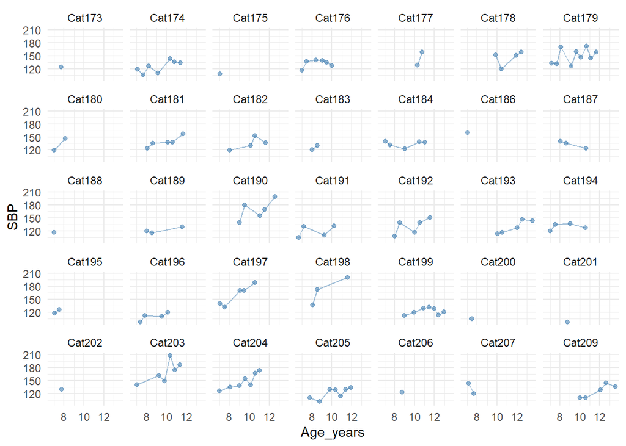

```r
ggplot(filter(Metadata_SBP2, Cat_ID %in% fourth),
             aes(Age_years, SBP, group = Cat_ID)) +
  facet_wrap(~ Cat_ID, ncol = 7) +
  geom_line(alpha = 0.5, colour = "steelblue") +
  geom_point(alpha = 0.6, colour = "steelblue") +
  theme_minimal() +
  theme(legend.position = "none")
```

##e. Linear mixed effects models for SBP changes with age. ###i. model 1 SBP, age, sex ####check splines

```r
#fit model for no splines up to 5df and compare
mod_b1<-lmer(SBP ~ Age_years + Sex + Age_years:Sex +(1|Cat_ID), Metadata_SBP2)
mod_b2<-lmer(SBP ~ ns(Age_years, df=2) + Sex + ns(Age_years, df=2):Sex +(1|Cat_ID), Metadata_SBP2)
mod_b3<-lmer(SBP ~ ns(Age_years, df=3) + Sex + ns(Age_years, df=3):Sex +(1|Cat_ID), Metadata_SBP2)
mod_b4<-lmer(SBP ~ ns(Age_years, df=4) + Sex + ns(Age_years, df=4):Sex +(1|Cat_ID), Metadata_SBP2)
mod_b5<-lmer(SBP ~ ns(Age_years, df=5) + Sex + ns(Age_years, df=5):Sex +(1|Cat_ID), Metadata_SBP2)

#compare
anova(mod_b1, mod_b2, mod_b3, mod_b4, mod_b5)
```

```
## refitting model(s) with ML (instead of REML)
```

```
## Data: Metadata_SBP2
## Models:
## mod_b1: SBP ~ Age_years + Sex + Age_years:Sex + (1 | Cat_ID)
## mod_b2: SBP ~ ns(Age_years, df = 2) + Sex + ns(Age_years, df = 2):Sex + (1 | Cat_ID)
## mod_b3: SBP ~ ns(Age_years, df = 3) + Sex + ns(Age_years, df = 3):Sex + (1 | Cat_ID)
## mod_b4: SBP ~ ns(Age_years, df = 4) + Sex + ns(Age_years, df = 4):Sex + (1 | Cat_ID)
## mod_b5: SBP ~ ns(Age_years, df = 5) + Sex + ns(Age_years, df = 5):Sex + (1 | Cat_ID)
##        npar    AIC    BIC  logLik -2*log(L)   Chisq Df Pr(>Chisq)
## mod_b1    6 9464.7 9494.8 -4726.3    9452.7
## mod_b2    8 9458.3 9498.4 -4721.1    9442.3 10.4054  2   0.005502 **
## mod_b3   10 9458.5 9508.6 -4719.2    9438.5  3.8032  2   0.149326
## mod_b4   12 9459.5 9519.7 -4717.8    9435.5  2.9554  2   0.228165
## mod_b5   14 9461.1 9531.3 -4716.5    9433.1  2.4222  2   0.297871
## ---
## Signif. codes:  0 '***' 0.001 '**' 0.01 '*' 0.05 '.' 0.1 ' ' 1
```

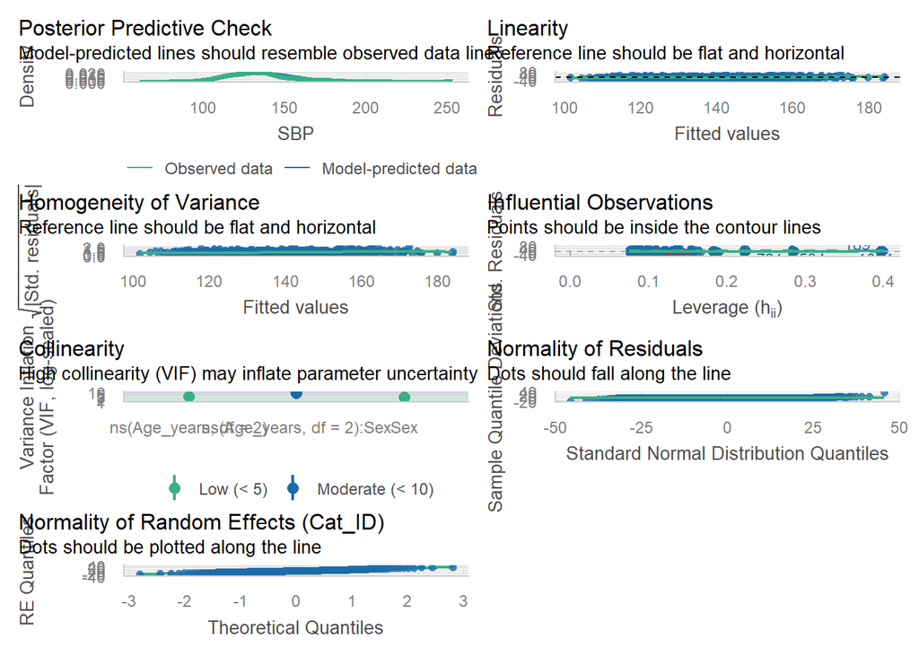

```r
#mod_b2 with 2df best

#check model assumptions

check_model(mod_b2)
```

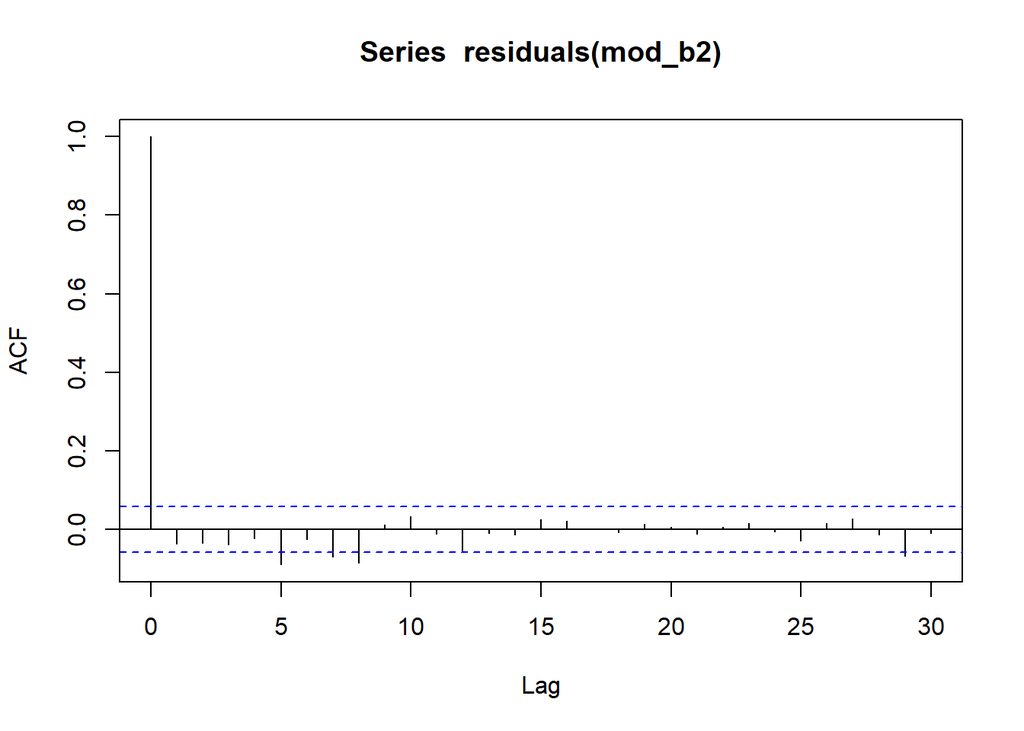

```r
acf(residuals(mod_b2))##ACF not showing stong autocorrelation. OK to use model.
```

```r
#png("check1.png", width = 2000, height = 3000, res = #300)
#print(check1)
#dev.off()
```

####add owner as nested re

```r
mod_b2_nested<-lmer(SBP ~ ns(Age_years, df=2) + Sex + ns(Age_years, df=2):Sex +(1|Owner_ID/Cat_ID), Metadata_SBP2)
summary(mod_b2_nested)
```

```
## Linear mixed model fit by REML ['lmerMod']
## Formula: SBP ~ ns(Age_years, df = 2) + Sex + ns(Age_years, df = 2):Sex +
##     (1 | Owner_ID/Cat_ID)
##    Data: Metadata_SBP2
##
## REML criterion at convergence: 9416.1
##
## Scaled residuals:
##     Min      1Q  Median      3Q     Max
## -4.2363 -0.6472 -0.0308  0.5527  5.4690
##
## Random effects:
##  Groups          Name        Variance Std.Dev.
##  Cat_ID:Owner_ID (Intercept) 116.77   10.806
##  Owner_ID        (Intercept)  22.07    4.698
##  Residual                    216.44   14.712
## Number of obs: 1116, groups:  Cat_ID:Owner_ID, 203; Owner_ID, 146
##
## Fixed effects:
##                                Estimate Std. Error t value
## (Intercept)                     116.024      2.429  47.769
## ns(Age_years, df = 2)1           42.539      4.869   8.737
## ns(Age_years, df = 2)2           27.982      4.058   6.896
## SexMale                           8.898      3.473   2.562
## ns(Age_years, df = 2)1:SexMale    2.762      6.898   0.400
## ns(Age_years, df = 2)2:SexMale   23.008      5.845   3.937
##
## Correlation of Fixed Effects:
##             (Intr) ns(A_,d=2)1 ns(A_,d=2)2 SexMal n(A_,d=2)1:
## ns(A_,d=2)1 -0.797
## ns(A_,d=2)2  0.095  0.124
## SexMale     -0.680  0.551      -0.069
## n(A_,d=2)1:  0.560 -0.705      -0.087      -0.801
## n(A_,d=2)2: -0.067 -0.086      -0.695       0.115  0.111
```

```r
tab_model(mod_b2_nested)
```

|  | SBP |  |  |
| --- | --- | --- | --- |
| Predictors | Estimates | CI | p |
| (Intercept) | 116.02 | 111.26 – 120.79 | **<0.001** |
| Age years [1st degree] | 42.54 | 32.99 – 52.09 | **<0.001** |
| Age years [2nd degree] | 27.98 | 20.02 – 35.94 | **<0.001** |
| Sex [Male] | 8.90 | 2.08 – 15.71 | **0.011** |
| Age years [1st degree] × Sex [Male] | 2.76 | -10.77 – 16.30 | 0.689 |
| Age years [2nd degree] × Sex [Male] | 23.01 | 11.54 – 34.48 | **<0.001** |
| Random Effects |  |  |  |
| σ<sup>2</sup> | 216.44 |  |  |
| τ<sub>00</sub> <sub>Cat_ID:Owner_ID</sub> | 116.77 |  |  |
| τ<sub>00</sub> <sub>Owner_ID</sub> | 22.07 |  |  |
| ICC | 0.39 |  |  |
| N <sub>Cat_ID</sub> | 203 |  |  |
| N <sub>Owner_ID</sub> | 146 |  |  |
| Observations | 1116 |  |  |
| Marginal R<sup>2</sup> / Conditional R<sup>2</sup> | 0.232 / 0.532 |  |  |

```r
anova(mod_b2, mod_b2_nested)
```

```
## refitting model(s) with ML (instead of REML)
```

```
## Data: Metadata_SBP2
## Models:
## mod_b2: SBP ~ ns(Age_years, df = 2) + Sex + ns(Age_years, df = 2):Sex + (1 | Cat_ID)
## mod_b2_nested: SBP ~ ns(Age_years, df = 2) + Sex + ns(Age_years, df = 2):Sex + (1 | Owner_ID/Cat_ID)
##               npar    AIC    BIC  logLik -2*log(L)  Chisq Df Pr(>Chisq)
## mod_b2           8 9458.3 9498.4 -4721.1    9442.3
## mod_b2_nested    9 9458.5 9503.7 -4720.2    9440.5 1.7768  1     0.1825
```

####check mod1 assumptions

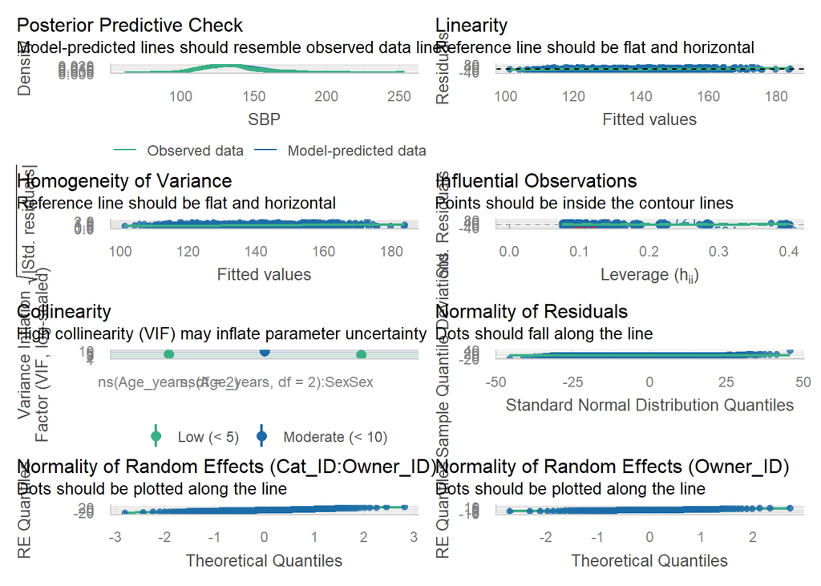

```r
check1<-check_model(mod_b2_nested)
print(check1)
```

```r
png("check1.png", width = 2000, height = 3000, res = 300)
print(check1)
dev.off()
```

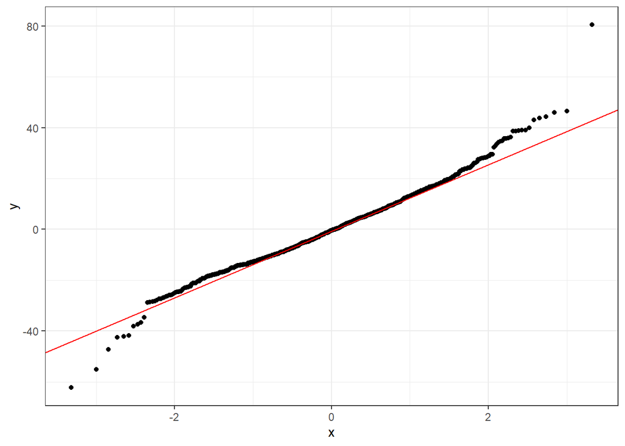

```r
# Extract residuals
res <- residuals(mod_b2_nested)
#qq plot of resids
ggplot(data.frame(res), aes(sample = res)) +
  stat_qq() +
  stat_qq_line(color = "red") +
  theme_bw()
```

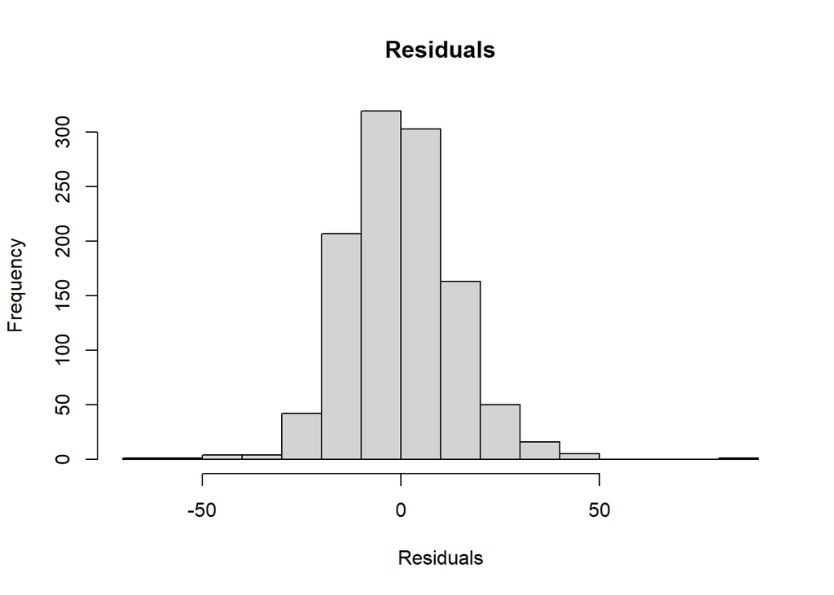

```r
#histogram of resids
hist(res, breaks = 20, main = "Residuals", xlab = "Residuals")
```

```r
#variance of random effects
VarCorr(mod_b2_nested)
```

```
##  Groups          Name        Std.Dev.
##  Cat_ID:Owner_ID (Intercept) 10.8058
##  Owner_ID        (Intercept)  4.6981
##  Residual                    14.7118
```

####compare overall effect of age with LRT

```r
mod_b2_noage<-lmer(SBP ~  Sex +  +(1|Owner_ID/Cat_ID), Metadata_SBP2)

anova(mod_b2_noage, mod_b2_nested)
```

```
## refitting model(s) with ML (instead of REML)
```

```
## Data: Metadata_SBP2
## Models:
## mod_b2_noage: SBP ~ Sex + +(1 | Owner_ID/Cat_ID)
## mod_b2_nested: SBP ~ ns(Age_years, df = 2) + Sex + ns(Age_years, df = 2):Sex + (1 | Owner_ID/Cat_ID)
##               npar    AIC    BIC  logLik -2*log(L)  Chisq Df Pr(>Chisq)
## mod_b2_noage     5 9728.8 9753.9 -4859.4    9718.8
## mod_b2_nested    9 9458.5 9503.7 -4720.2    9440.5 278.35  4  < 2.2e-16 ***
## ---
## Signif. codes:  0 '***' 0.001 '**' 0.01 '*' 0.05 '.' 0.1 ' ' 1
```

```r
#mod with age significantly improves model fit P<0.001
```

###ii. model2: sbp, age, sex, diseases ####ensure data ordered correctly

```r
Metadata_SBP2 <- Metadata_SBP2 %>%
  mutate(MCS_grade_None_Mild_Moderate_to_Severe = case_when(
    MCS_combined == 30 ~ "None",
    MCS_combined %in% 20:29 ~ "Mild",
    MCS_combined %in% 0:19 ~ "Moderate to severe",
    TRUE ~ NA_character_
  ))

Metadata_SBP2$MCS_grade_None_Mild_Moderate_to_Severe<-factor(Metadata_SBP2$MCS_grade_None_Mild_Moderate_to_Severe, levels= c( "None", "Mild", "Moderate to severe"))
```

#####arrange BCS into categories

```r
Metadata_SBP2 <- Metadata_SBP2 %>%
  mutate(BCS_group3 = case_when(
    BCS %in% 1:4 ~ "1-4",
    BCS == 5     ~ "5",
    BCS == 6     ~ "6",
    BCS %in% 7:9 ~ "7-9",
    TRUE ~ NA_character_
  ))
#set ref category as 5
Metadata_SBP2  <- Metadata_SBP2  %>%
  mutate(BCS_group3 = factor(
    BCS_group3,
    levels = c("5", "1-4", "6", "7-9")
  ))
# Count cats in each category
cat_counts <- Metadata_SBP2  %>%
  count(BCS_group3)
cat_counts
```

```
##   BCS_group3   n
## 1          5 308
## 2        1-4 143
## 3          6 267
## 4        7-9 392
## 5       <NA>   6
```

##### group HM

```r
Metadata_SBP2<-Metadata_SBP2%>%
  mutate(
    HM_group = case_when(
      HM_grade == 0 ~ "None",
      HM_grade %in% c(1,2) ~ "I-II/VI",
      HM_grade >=3 ~ "≥III/VI",
      TRUE ~ NA_character_
    ))
#
levels(Metadata_SBP2$HM_group)
```

```r
#
as.factor(Metadata_SBP2$HM_group)
```

[output not shown]

[output cut: 110 more lines]

```r
#
Metadata_SBP2$HM_group<-factor(Metadata_SBP2$HM_group, levels = c("None", "I-II/VI", "≥III/VI"))
```

#####group muscle loss

```r
Metadata_SBP2<-Metadata_SBP2%>%
  mutate(
    MCS_binary= case_when(
       MCS_combined == 30 ~ "None",
       MCS_combined %in% c(0:29) ~ "Muscle loss",
      TRUE ~ NA_character_
    ))
#
levels(Metadata_SBP2$MCS_binary)
```

```r
#
as.factor(Metadata_SBP2$MCS_binary)
```

[output not shown]

[output cut: 172 more lines]

```r
#
Metadata_SBP2$MCS_binary<-factor(Metadata_SBP2$MCS_binary, levels = c("None", "Muscle loss"))

# Count cats in each category
cat_counts <- Metadata_SBP2  %>%
  count(MCS_binary)
cat_counts
```

```
##    MCS_binary   n
## 1        None 509
## 2 Muscle loss 557
## 3        <NA>  50
```

####run model

```r
mod_bc <- lmer(SBP ~ ns(Age_years, df = 2) + Sex + ns(Age_years, df=2):Sex + Breed + BCS_group3 + MCS_grade_None_Mild_Moderate_to_Severe +
                 CKD + Hyperthyroidism +  Neoplasia +
                 Heart_murmur + Diabetes_mellitus + Dental_disease + oe.abnormalities_Yes_no_incomplete +
                 (1 | Cat_ID), data = Metadata_SBP2)

summary(mod_bc)
```

```
## Linear mixed model fit by REML ['lmerMod']
## Formula: SBP ~ ns(Age_years, df = 2) + Sex + ns(Age_years, df = 2):Sex +
##     Breed + BCS_group3 + MCS_grade_None_Mild_Moderate_to_Severe +
##     CKD + Hyperthyroidism + Neoplasia + Heart_murmur + Diabetes_mellitus +
##     Dental_disease + oe.abnormalities_Yes_no_incomplete + (1 |      Cat_ID)
##    Data: Metadata_SBP2
##
## REML criterion at convergence: 8137.5
##
## Scaled residuals:
##     Min      1Q  Median      3Q     Max
## -3.6430 -0.6426 -0.0251  0.5460  5.6600
##
## Random effects:
##  Groups   Name        Variance Std.Dev.
##  Cat_ID   (Intercept) 130.6    11.43
##  Residual             206.6    14.38
## Number of obs: 976, groups:  Cat_ID, 199
##
## Fixed effects:
##                                                          Estimate Std. Error
## (Intercept)                                              112.2382     2.9066
## ns(Age_years, df = 2)1                                    33.6093     5.4416
## ns(Age_years, df = 2)2                                    19.7707     4.7767
## SexMale                                                    9.7005     3.5480
## BreedPedigree                                              4.0659     2.8766
## BCS_group31-4                                             -2.3629     1.9465
## BCS_group36                                                2.9250     1.5487
## BCS_group37-9                                              6.1532     1.6716
## MCS_grade_None_Mild_Moderate_to_SevereMild                 4.9895     1.3048
## MCS_grade_None_Mild_Moderate_to_SevereModerate to severe   7.0985     3.0094
## CKDYes                                                     4.7327     2.7974
## HyperthyroidismYes                                        11.2173     2.8629
## NeoplasiaYes                                             -18.7080     5.9464
## Heart_murmurYes                                            0.6048     1.2681
## Diabetes_mellitusYes                                      -6.0730     6.5519
## Dental_diseaseYes                                          1.4326     1.1039
## oe.abnormalities_Yes_no_incompleteIncomplete_OE           -0.4639     1.8166
## oe.abnormalities_Yes_no_incompleteYes                      0.5048     1.6997
## ns(Age_years, df = 2)1:SexMale                            -0.7438     7.1396
## ns(Age_years, df = 2)2:SexMale                            23.4843     6.0832
##                                                          t value
## (Intercept)                                               38.615
## ns(Age_years, df = 2)1                                     6.176
## ns(Age_years, df = 2)2                                     4.139
## SexMale                                                    2.734
## BreedPedigree                                              1.413
## BCS_group31-4                                             -1.214
## BCS_group36                                                1.889
## BCS_group37-9                                              3.681
## MCS_grade_None_Mild_Moderate_to_SevereMild                 3.824
## MCS_grade_None_Mild_Moderate_to_SevereModerate to severe   2.359
## CKDYes                                                     1.692
## HyperthyroidismYes                                         3.918
## NeoplasiaYes                                              -3.146
## Heart_murmurYes                                            0.477
## Diabetes_mellitusYes                                      -0.927
## Dental_diseaseYes                                          1.298
## oe.abnormalities_Yes_no_incompleteIncomplete_OE           -0.255
## oe.abnormalities_Yes_no_incompleteYes                      0.297
## ns(Age_years, df = 2)1:SexMale                            -0.104
## ns(Age_years, df = 2)2:SexMale                             3.861
```

```
##
## Correlation matrix not shown by default, as p = 20 > 12.
## Use print(x, correlation=TRUE)  or
##     vcov(x)        if you need it
```

#####check N per disease in this model

[output not shown]

#####owner nested

```r
mod_bc_nested <- lmer(SBP ~ ns(Age_years, df = 2) + Sex + ns(Age_years, df=2):Sex + Breed + BCS_group3 + MCS_grade_None_Mild_Moderate_to_Severe +
                 CKD + Hyperthyroidism +  Neoplasia +
                 HM_group + HR + Diabetes_mellitus + Dental_disease  + (1 | Owner_ID/Cat_ID), data = Metadata_SBP2)

tab_model(mod_bc_nested)
```

|  | SBP |  |  |
| --- | --- | --- | --- |
| Predictors | Estimates | CI | p |
| (Intercept) | 100.54 | 89.82 – 111.26 | **<0.001** |
| Age years [1st degree] | 34.85 | 24.31 – 45.39 | **<0.001** |
| Age years [2nd degree] | 21.33 | 12.00 – 30.66 | **<0.001** |
| Sex [Male] | 10.74 | 3.89 – 17.59 | **0.002** |
| Breed [Pedigree] | 4.41 | -1.07 – 9.90 | 0.115 |
| BCS_group31-4 | -2.93 | -6.75 – 0.88 | 0.132 |
| BCS group3 [6] | 2.15 | -0.80 – 5.09 | 0.153 |
| BCS_group37-9 | 5.34 | 2.18 – 8.51 | **0.001** |
| MCS grade None Mild Moderate to Severe [Mild] | 5.48 | 2.97 – 7.99 | **<0.001** |
| MCS grade None Mild Moderate to Severe [Moderate to severe] | 7.57 | 1.69 – 13.46 | **0.012** |
| CKD [Yes] | 4.56 | -0.80 – 9.92 | 0.095 |
| Hyperthyroidism [Yes] | 10.45 | 4.93 – 15.96 | **<0.001** |
| Neoplasia [Yes] | -18.05 | -29.69 – -6.40 | **0.002** |
| HM group [I-II/VI] | 0.71 | -1.81 – 3.23 | 0.581 |
| HM group [≥III/VI] | -1.56 | -6.60 – 3.48 | 0.544 |
| HR | 0.06 | 0.01 – 0.11 | **0.016** |
| Diabetes mellitus [Yes] | -5.86 | -18.67 – 6.95 | 0.370 |
| Dental disease [Yes] | 1.64 | -0.48 – 3.75 | 0.129 |
| Age years [1st degree] × Sex [Male] | -3.06 | -16.95 – 10.83 | 0.666 |
| Age years [2nd degree] × Sex [Male] | 21.18 | 9.25 – 33.11 | **0.001** |
| Random Effects |  |  |  |
| σ<sup>2</sup> | 208.83 |  |  |
| τ<sub>00</sub> <sub>Cat_ID:Owner_ID</sub> | 97.87 |  |  |
| τ<sub>00</sub> <sub>Owner_ID</sub> | 19.36 |  |  |
| ICC | 0.36 |  |  |
| N <sub>Cat_ID</sub> | 199 |  |  |
| N <sub>Owner_ID</sub> | 143 |  |  |
| Observations | 1022 |  |  |
| Marginal R<sup>2</sup> / Conditional R<sup>2</sup> | 0.285 / 0.542 |  |  |

#####compare splines

```r
mod_bc_nested2 <- lmer(SBP ~ Age_years + Sex + Age_years:Sex + Breed + BCS_group3 + MCS_grade_None_Mild_Moderate_to_Severe +
                 CKD + Hyperthyroidism +  Neoplasia +
                 HM_group + HR + Diabetes_mellitus + Dental_disease  + (1 | Owner_ID/Cat_ID), data = Metadata_SBP2)


anova(mod_bc_nested, mod_bc_nested2)#splines significantly improve model
```

```
## refitting model(s) with ML (instead of REML)
```

```
## Data: Metadata_SBP2
## Models:
## mod_bc_nested2: SBP ~ Age_years + Sex + Age_years:Sex + Breed + BCS_group3 + MCS_grade_None_Mild_Moderate_to_Severe + CKD + Hyperthyroidism + Neoplasia + HM_group + HR + Diabetes_mellitus + Dental_disease + (1 | Owner_ID/Cat_ID)
## mod_bc_nested: SBP ~ ns(Age_years, df = 2) + Sex + ns(Age_years, df = 2):Sex + Breed + BCS_group3 + MCS_grade_None_Mild_Moderate_to_Severe + CKD + Hyperthyroidism + Neoplasia + HM_group + HR + Diabetes_mellitus + Dental_disease + (1 | Owner_ID/Cat_ID)
##                npar    AIC    BIC  logLik -2*log(L)  Chisq Df Pr(>Chisq)
## mod_bc_nested2   21 8637.3 8740.8 -4297.7    8595.3
## mod_bc_nested    23 8629.0 8742.4 -4291.5    8583.0 12.306  2   0.002128 **
## ---
## Signif. codes:  0 '***' 0.001 '**' 0.01 '*' 0.05 '.' 0.1 ' ' 1
```

```r
AIC(mod_bc_nested, mod_bc_nested2)
```

```
##                df      AIC
## mod_bc_nested  23 8565.854
## mod_bc_nested2 21 8593.827
```

#####check mod 2 assumptions

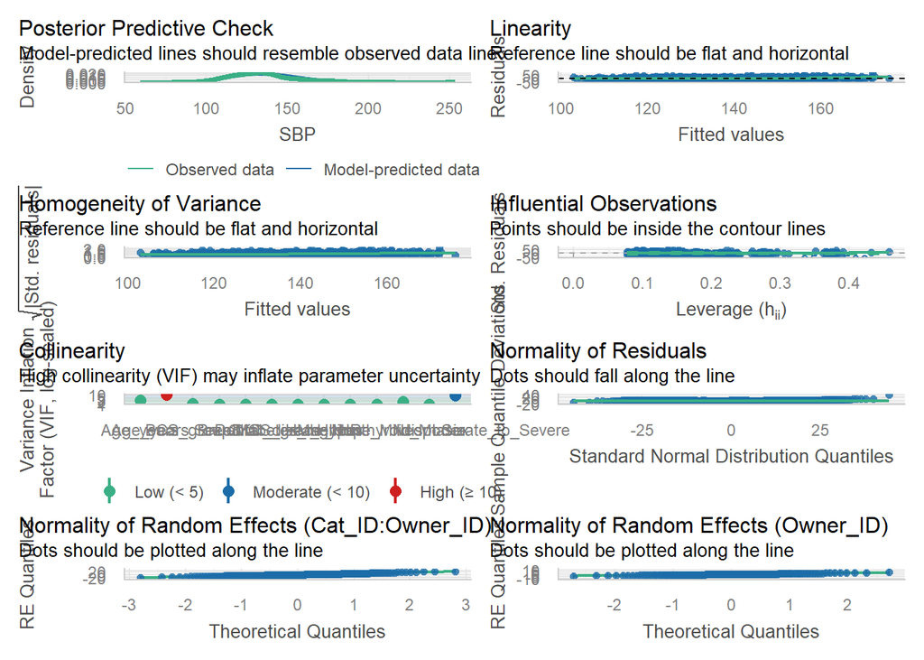

```r
check2<-check_model(mod_bc_nested2)
print(check2)
```

```r
check_collinearity(mod_bc_nested2)
```

```
## Model has interaction terms. VIFs might be inflated.
##   Try to center the variables used for the interaction, or check
##   multicollinearity among predictors of a model without interaction terms.
```

```
## # Check for Multicollinearity
##
## Low Correlation
##
##                                    Term  VIF    VIF 95% CI adj. VIF Tolerance
##                               Age_years 2.76 [2.51,  3.05]     1.66      0.36
##                                   Breed 1.03 [1.00,  1.25]     1.01      0.97
##                              BCS_group3 1.31 [1.23,  1.43]     1.15      0.76
##  MCS_grade_None_Mild_Moderate_to_Severe 1.97 [1.81,  2.17]     1.40      0.51
##                                     CKD 1.05 [1.01,  1.19]     1.03      0.95
##                         Hyperthyroidism 1.14 [1.08,  1.24]     1.07      0.88
##                               Neoplasia 1.09 [1.04,  1.19]     1.04      0.92
##                                HM_group 1.11 [1.06,  1.21]     1.05      0.90
##                                      HR 1.04 [1.01,  1.20]     1.02      0.96
##                       Diabetes_mellitus 1.02 [1.00,  1.36]     1.01      0.98
##                          Dental_disease 1.01 [1.00,  1.96]     1.01      0.99
##  Tolerance 95% CI
##      [0.33, 0.40]
##      [0.80, 1.00]
##      [0.70, 0.81]
##      [0.46, 0.55]
##      [0.84, 0.99]
##      [0.80, 0.93]
##      [0.84, 0.96]
##      [0.82, 0.95]
##      [0.83, 0.99]
##      [0.74, 1.00]
##      [0.51, 1.00]
##
## Moderate Correlation
##
##  Term  VIF    VIF 95% CI adj. VIF Tolerance Tolerance 95% CI
##   Sex 9.28 [8.29, 10.40]     3.05      0.11     [0.10, 0.12]
##
## High Correlation
##
##           Term   VIF    VIF 95% CI adj. VIF Tolerance Tolerance 95% CI
##  Age_years:Sex 10.50 [9.37, 11.79]     3.24      0.10     [0.08, 0.11]
```

```r
png("check2.png", width = 2000, height = 3000, res = 300)
print(check2)
dev.off()
```

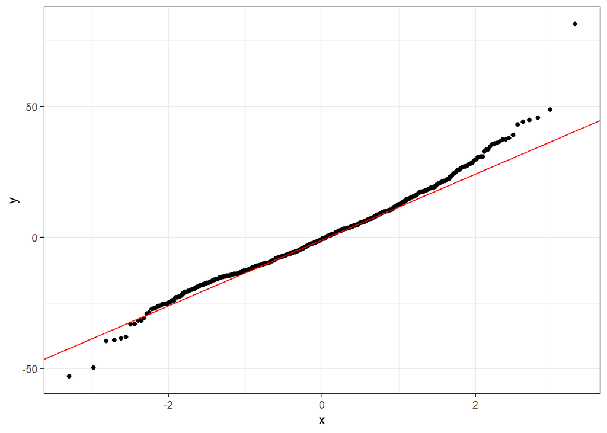

```r
# Extract residuals
res <- residuals(mod_bc_nested2)
#qq plot of resids
ggplot(data.frame(res), aes(sample = res)) +
  stat_qq() +
  stat_qq_line(color = "red") +
  theme_bw()
```

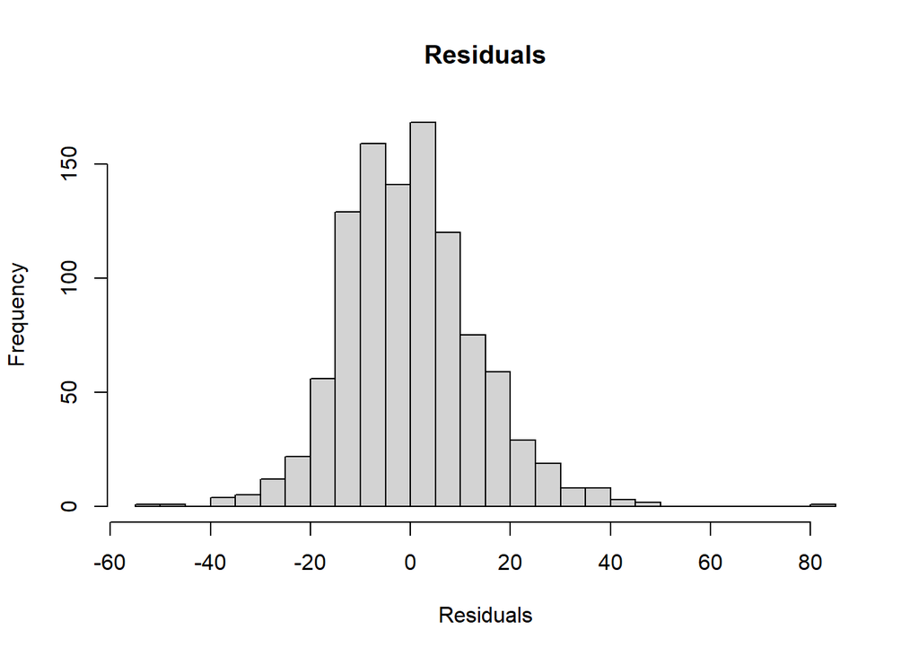

```r
#histogram of resids
hist(res, breaks = 20, main = "Residuals", xlab = "Residuals")
```

#####LRT to compare overall effect of age

```r
mod_bc_noage<- lmer(SBP ~  + Sex + Breed + BCS_group3 + MCS_grade_None_Mild_Moderate_to_Severe +
                 CKD + Hyperthyroidism +  Neoplasia +
                 HM_group + HR + Diabetes_mellitus + Dental_disease  + (1 | Owner_ID/Cat_ID), data = Metadata_SBP2)

anova(mod_bc_noage, mod_bc_nested)
```

```
## refitting model(s) with ML (instead of REML)
```

```
## Data: Metadata_SBP2
## Models:
## mod_bc_noage: SBP ~ +Sex + Breed + BCS_group3 + MCS_grade_None_Mild_Moderate_to_Severe + CKD + Hyperthyroidism + Neoplasia + HM_group + HR + Diabetes_mellitus + Dental_disease + (1 | Owner_ID/Cat_ID)
## mod_bc_nested: SBP ~ ns(Age_years, df = 2) + Sex + ns(Age_years, df = 2):Sex + Breed + BCS_group3 + MCS_grade_None_Mild_Moderate_to_Severe + CKD + Hyperthyroidism + Neoplasia + HM_group + HR + Diabetes_mellitus + Dental_disease + (1 | Owner_ID/Cat_ID)
##               npar  AIC    BIC  logLik -2*log(L)  Chisq Df Pr(>Chisq)
## mod_bc_noage    19 8732 8825.7 -4347.0      8694
## mod_bc_nested   23 8629 8742.4 -4291.5      8583 111.01  4  < 2.2e-16 ***
## ---
## Signif. codes:  0 '***' 0.001 '**' 0.01 '*' 0.05 '.' 0.1 ' ' 1
```

```r
#Age significantly improved model P<0.001
```

##iii. mod 3 subset for OE score

```r
mod_oe_nested <- lmer(SBP ~ ns(Age_years, df = 2) + Sex + ns(Age_years, df=2):Sex + Breed + BCS_group3 + MCS_grade_None_Mild_Moderate_to_Severe +
                 CKD + Hyperthyroidism +  Neoplasia +
                 HM_group + HR + Diabetes_mellitus + Dental_disease + oe.abnormality_score +  (1 | Owner_ID/Cat_ID), data = Metadata_SBP2)

tab_model(mod_oe_nested)
```

|  | SBP |  |  |
| --- | --- | --- | --- |
| Predictors | Estimates | CI | p |
| (Intercept) | 100.14 | 86.26 – 114.03 | **<0.001** |
| Age years [1st degree] | 27.73 | 13.42 – 42.03 | **<0.001** |
| Age years [2nd degree] | 16.59 | 5.10 – 28.09 | **0.005** |
| Sex [Male] | 12.41 | 3.49 – 21.33 | **0.006** |
| Breed [Pedigree] | 4.74 | -1.72 – 11.20 | 0.150 |
| BCS_group31-4 | 0.51 | -4.41 – 5.43 | 0.838 |
| BCS group3 [6] | 2.77 | -1.03 – 6.58 | 0.153 |
| BCS_group37-9 | 5.39 | 1.21 – 9.56 | **0.012** |
| MCS grade None Mild Moderate to Severe [Mild] | 4.61 | 1.21 – 8.02 | **0.008** |
| MCS grade None Mild Moderate to Severe [Moderate to severe] | 4.59 | -2.71 – 11.88 | 0.217 |
| CKD [Yes] | 3.32 | -2.87 – 9.52 | 0.293 |
| Hyperthyroidism [Yes] | 14.94 | 7.86 – 22.02 | **<0.001** |
| Neoplasia [Yes] | -4.35 | -19.27 – 10.57 | 0.567 |
| HM group [I-II/VI] | -0.25 | -3.38 – 2.89 | 0.878 |
| HM group [≥III/VI] | -4.22 | -10.16 – 1.73 | 0.164 |
| HR | 0.06 | 0.00 – 0.13 | **0.038** |
| Diabetes mellitus [Yes] | -9.13 | -22.82 – 4.56 | 0.191 |
| Dental disease [Yes] | 0.80 | -2.03 – 3.63 | 0.578 |
| oe abnormality score | 0.54 | 0.04 – 1.04 | **0.035** |
| Age years [1st degree] × Sex [Male] | -3.46 | -21.84 – 14.91 | 0.712 |
| Age years [2nd degree] × Sex [Male] | 20.26 | 6.19 – 34.34 | **0.005** |
| Random Effects |  |  |  |
| σ<sup>2</sup> | 185.58 |  |  |
| τ<sub>00</sub> <sub>Cat_ID:Owner_ID</sub> | 116.93 |  |  |
| τ<sub>00</sub> <sub>Owner_ID</sub> | 21.05 |  |  |
| ICC | 0.43 |  |  |
| N <sub>Cat_ID</sub> | 168 |  |  |
| N <sub>Owner_ID</sub> | 124 |  |  |
| Observations | 561 |  |  |
| Marginal R<sup>2</sup> / Conditional R<sup>2</sup> | 0.310 / 0.604 |  |  |

#####check mod 3 assumptions

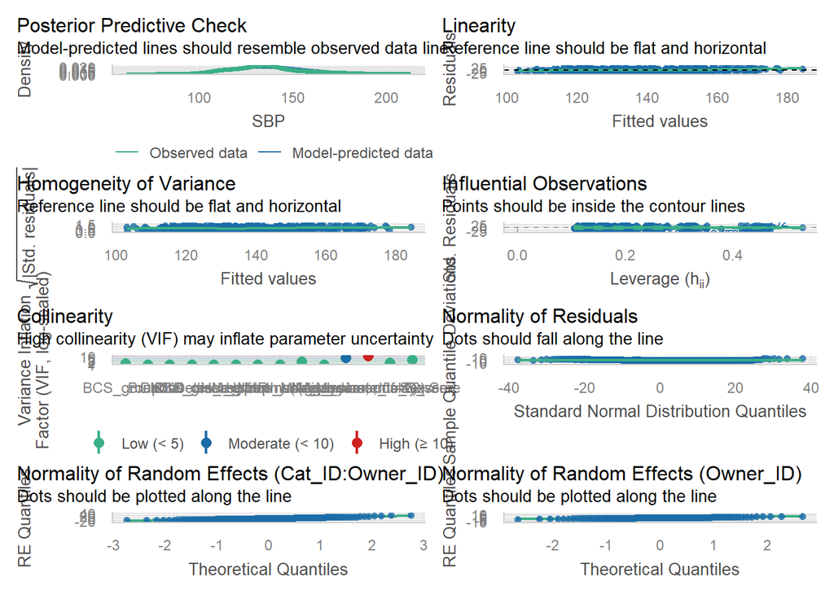

```r
check3<-check_model(mod_oe_nested)
print(check3)
```

```r
check_collinearity(mod_oe_nested)
```

```
## Model has interaction terms. VIFs might be inflated.
##   Try to center the variables used for the interaction, or check
##   multicollinearity among predictors of a model without interaction terms.
```

```
## # Check for Multicollinearity
##
## Low Correlation
##
##                                    Term  VIF    VIF 95% CI adj. VIF Tolerance
##                                     Sex 4.01 [3.50,  4.62]     2.00      0.25
##                                   Breed 1.03 [1.00,  1.41]     1.02      0.97
##                              BCS_group3 1.51 [1.37,  1.70]     1.07      0.66
##  MCS_grade_None_Mild_Moderate_to_Severe 2.49 [2.20,  2.84]     1.26      0.40
##                                     CKD 1.07 [1.02,  1.25]     1.04      0.93
##                         Hyperthyroidism 1.10 [1.04,  1.26]     1.05      0.91
##                               Neoplasia 1.11 [1.05,  1.27]     1.05      0.90
##                                HM_group 1.14 [1.07,  1.29]     1.03      0.88
##                                      HR 1.09 [1.03,  1.25]     1.04      0.92
##                       Diabetes_mellitus 1.05 [1.01,  1.29]     1.02      0.95
##                          Dental_disease 1.03 [1.00,  1.42]     1.02      0.97
##                    oe.abnormality_score 1.87 [1.68,  2.12]     1.37      0.53
##  Tolerance 95% CI
##      [0.22, 0.29]
##      [0.71, 1.00]
##      [0.59, 0.73]
##      [0.35, 0.45]
##      [0.80, 0.98]
##      [0.79, 0.96]
##      [0.79, 0.95]
##      [0.78, 0.94]
##      [0.80, 0.97]
##      [0.78, 0.99]
##      [0.71, 1.00]
##      [0.47, 0.60]
##
## Moderate Correlation
##
##                   Term  VIF    VIF 95% CI adj. VIF Tolerance Tolerance 95% CI
##  ns(Age_years, df = 2) 6.78 [5.87,  7.87]     2.60      0.15     [0.13, 0.17]
##
## High Correlation
##
##                       Term   VIF    VIF 95% CI adj. VIF Tolerance
##  ns(Age_years, df = 2):Sex 11.37 [9.78, 13.24]     3.37      0.09
##  Tolerance 95% CI
##      [0.08, 0.10]
```

```r
png("check3.png", width = 2000, height = 3000, res = 300)
print(check3)
dev.off()
```

```r
check_collinearity(mod_oe_nested)
```

```
## Model has interaction terms. VIFs might be inflated.
##   Try to center the variables used for the interaction, or check
##   multicollinearity among predictors of a model without interaction terms.
```

```
## # Check for Multicollinearity
##
## Low Correlation
##
##                                    Term  VIF    VIF 95% CI adj. VIF Tolerance
##                                     Sex 4.01 [3.50,  4.62]     2.00      0.25
##                                   Breed 1.03 [1.00,  1.41]     1.02      0.97
##                              BCS_group3 1.51 [1.37,  1.70]     1.07      0.66
##  MCS_grade_None_Mild_Moderate_to_Severe 2.49 [2.20,  2.84]     1.26      0.40
##                                     CKD 1.07 [1.02,  1.25]     1.04      0.93
##                         Hyperthyroidism 1.10 [1.04,  1.26]     1.05      0.91
##                               Neoplasia 1.11 [1.05,  1.27]     1.05      0.90
##                                HM_group 1.14 [1.07,  1.29]     1.03      0.88
##                                      HR 1.09 [1.03,  1.25]     1.04      0.92
##                       Diabetes_mellitus 1.05 [1.01,  1.29]     1.02      0.95
##                          Dental_disease 1.03 [1.00,  1.42]     1.02      0.97
##                    oe.abnormality_score 1.87 [1.68,  2.12]     1.37      0.53
##  Tolerance 95% CI
##      [0.22, 0.29]
##      [0.71, 1.00]
##      [0.59, 0.73]
##      [0.35, 0.45]
##      [0.80, 0.98]
##      [0.79, 0.96]
##      [0.79, 0.95]
##      [0.78, 0.94]
##      [0.80, 0.97]
##      [0.78, 0.99]
##      [0.71, 1.00]
##      [0.47, 0.60]
##
## Moderate Correlation
##
##                   Term  VIF    VIF 95% CI adj. VIF Tolerance Tolerance 95% CI
##  ns(Age_years, df = 2) 6.78 [5.87,  7.87]     2.60      0.15     [0.13, 0.17]
##
## High Correlation
##
##                       Term   VIF    VIF 95% CI adj. VIF Tolerance
##  ns(Age_years, df = 2):Sex 11.37 [9.78, 13.24]     3.37      0.09
##  Tolerance 95% CI
##      [0.08, 0.10]
```

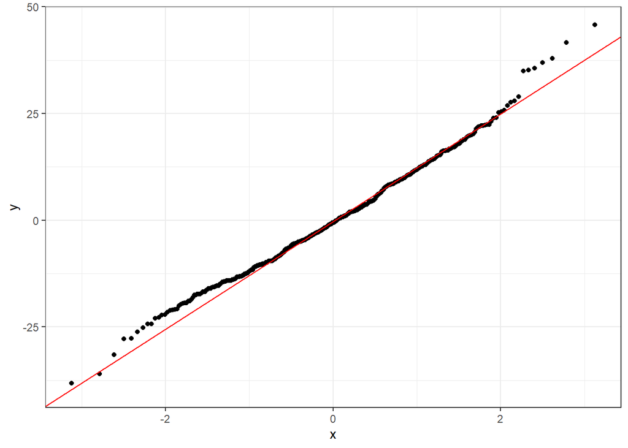

```r
# Extract residuals
res <- residuals(mod_oe_nested)
#qq plot of resids
ggplot(data.frame(res), aes(sample = res)) +
  stat_qq() +
  stat_qq_line(color = "red") +
  theme_bw()
```

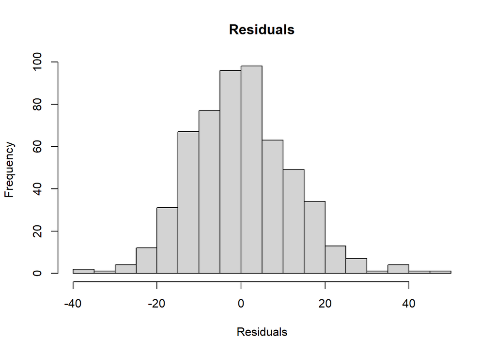

```r
#histogram of resids
hist(res, breaks = 20, main = "Residuals", xlab = "Residuals")
```

##iv. sensitivity analyses ####Now subset by healthy cats only

```r
Metadata_healthy<-Metadata_SBP2%>%
  filter(Healthy_visit=="Yes")

dim(Metadata_healthy)
```

```
## [1] 707  44
```

```r
Metadata_healthy%>%
  filter(Hypertension=="Yes")
```

```
##    Cat_ID_timepoint Cat_ID Owner_ID timepoint       date        dob Age_years
## 1          Cat005_0 Cat005   Own005       0.0 28/03/2017 04/06/2009  7.813826
## 2          Cat006_1 Cat006   Own006       1.0 21/03/2018 21/09/2009  8.495551
## 3        Cat006_2.5 Cat006   Own006       2.5 07/11/2019 21/09/2009 10.127310
## 4          Cat014_2 Cat014   Own011       2.0 02/05/2019 15/05/2010  8.963723
## 5          Cat015_0 Cat015   Own012       0.0 31/05/2017 03/09/2007  9.741273
## 6        Cat017_2.5 Cat017   Own014       2.5 15/10/2019 01/02/2008 11.701574
## 7          Cat027_0 Cat027   Own022       0.0 27/06/2017 04/02/2009  8.391513
## 8        Cat029_2.5 Cat029   Own023       2.5 28/01/2020 12/12/2007 12.128679
## 9        Cat038_0.5 Cat038   Own031       0.5 21/02/2018 05/10/2007 10.381930
## 10         Cat048_3 Cat048   Own039       3.0 05/11/2020 19/07/2008 12.298426
## 11         Cat051_1 Cat051   Own042       1.0 11/09/2018 27/10/2008  9.872690
## 12         Cat051_2 Cat051   Own042       2.0 10/12/2019 27/10/2008 11.118412
## 13       Cat051_3.5 Cat051   Own042       3.5 01/06/2021 27/10/2008 12.594114
## 14       Cat067_4.5 Cat067   Own047       4.5 22/06/2022 27/09/2010 11.734428
```

[output cut: 282 more lines]

```r
mod_healthy<-lmer(SBP ~ ns(Age_years, df = 2) + Sex + ns(Age_years, df=2):Sex + (1|Owner_ID/Cat_ID), Metadata_healthy)
mod_healthy2<-lmer(SBP ~ ns(Age_years, df = 3) + Sex + ns(Age_years, df=3):Sex + (1|Owner_ID/Cat_ID), Metadata_healthy)
tab_model(mod_healthy2)
```

|  | SBP |  |  |
| --- | --- | --- | --- |
| Predictors | Estimates | CI | p |
| (Intercept) | 115.22 | 108.51 – 121.92 | **<0.001** |
| Age years [1st degree] | 14.25 | 7.48 – 21.02 | **<0.001** |
| Age years [2nd degree] | 30.06 | 14.40 – 45.72 | **<0.001** |
| Age years [3rd degree] | 16.33 | 6.35 – 26.30 | **0.001** |
| Sex [Male] | 12.00 | 2.29 – 21.71 | **0.016** |
| Age years [1st degree] × Sex [Male] | 0.22 | -10.32 – 10.75 | 0.968 |
| Age years [2nd degree] × Sex [Male] | -13.61 | -38.10 – 10.88 | 0.276 |
| Age years [3rd degree] × Sex [Male] | 6.41 | -13.72 – 26.55 | 0.532 |
| Random Effects |  |  |  |
| σ<sup>2</sup> | 184.27 |  |  |
| τ<sub>00</sub> <sub>Cat_ID:Owner_ID</sub> | 57.00 |  |  |
| τ<sub>00</sub> <sub>Owner_ID</sub> | 8.99 |  |  |
| ICC | 0.26 |  |  |
| N <sub>Cat_ID</sub> | 170 |  |  |
| N <sub>Owner_ID</sub> | 125 |  |  |
| Observations | 707 |  |  |
| Marginal R<sup>2</sup> / Conditional R<sup>2</sup> | 0.111 / 0.346 |  |  |

```r
mod_healthy3<-lmer(SBP ~ Age_years + Sex + Age_years:Sex + (1|Owner_ID/Cat_ID), Metadata_healthy)

anova(mod_healthy, mod_healthy2, mod_healthy3)
```

```
## refitting model(s) with ML (instead of REML)
```

```
## Data: Metadata_healthy
## Models:
## mod_healthy3: SBP ~ Age_years + Sex + Age_years:Sex + (1 | Owner_ID/Cat_ID)
## mod_healthy: SBP ~ ns(Age_years, df = 2) + Sex + ns(Age_years, df = 2):Sex + (1 | Owner_ID/Cat_ID)
## mod_healthy2: SBP ~ ns(Age_years, df = 3) + Sex + ns(Age_years, df = 3):Sex + (1 | Owner_ID/Cat_ID)
##              npar    AIC    BIC  logLik -2*log(L)  Chisq Df Pr(>Chisq)
## mod_healthy3    7 5850.4 5882.3 -2918.2    5836.4
## mod_healthy     9 5849.5 5890.6 -2915.8    5831.5 4.8735  2    0.08745 .
## mod_healthy2   11 5851.8 5901.9 -2914.9    5829.8 1.7705  2    0.41261
## ---
## Signif. codes:  0 '***' 0.001 '**' 0.01 '*' 0.05 '.' 0.1 ' ' 1
```

```r
tab_model(mod_healthy)
```

|  | SBP |  |  |
| --- | --- | --- | --- |
| Predictors | Estimates | CI | p |
| (Intercept) | 116.06 | 110.98 – 121.13 | **<0.001** |
| Age years [1st degree] | 30.79 | 20.05 – 41.54 | **<0.001** |
| Age years [2nd degree] | 13.13 | 4.60 – 21.67 | **0.003** |
| Sex [Male] | 8.35 | 0.88 – 15.83 | **0.029** |
| Age years [1st degree] × Sex [Male] | -4.11 | -19.63 – 11.42 | 0.604 |
| Age years [2nd degree] × Sex [Male] | 16.51 | 0.76 – 32.26 | **0.040** |
| Random Effects |  |  |  |
| σ<sup>2</sup> | 183.45 |  |  |
| τ<sub>00</sub> <sub>Cat_ID:Owner_ID</sub> | 57.61 |  |  |
| τ<sub>00</sub> <sub>Owner_ID</sub> | 10.25 |  |  |
| ICC | 0.27 |  |  |
| N <sub>Cat_ID</sub> | 170 |  |  |
| N <sub>Owner_ID</sub> | 125 |  |  |
| Observations | 707 |  |  |
| Marginal R<sup>2</sup> / Conditional R<sup>2</sup> | 0.110 / 0.350 |  |  |

```
## Some of the focal terms are of type `character`. This may lead to
##   unexpected results. It is recommended to convert these variables to
##   factors before fitting the model.
##   The following variables are of type character: `Sex`
```

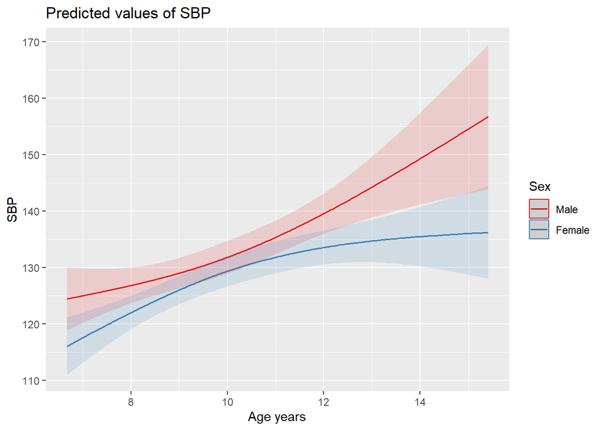

```r
plot_model(mod_healthy, type="pred", terms=c("Age_years[all]", "Sex"), show.data=F)
```

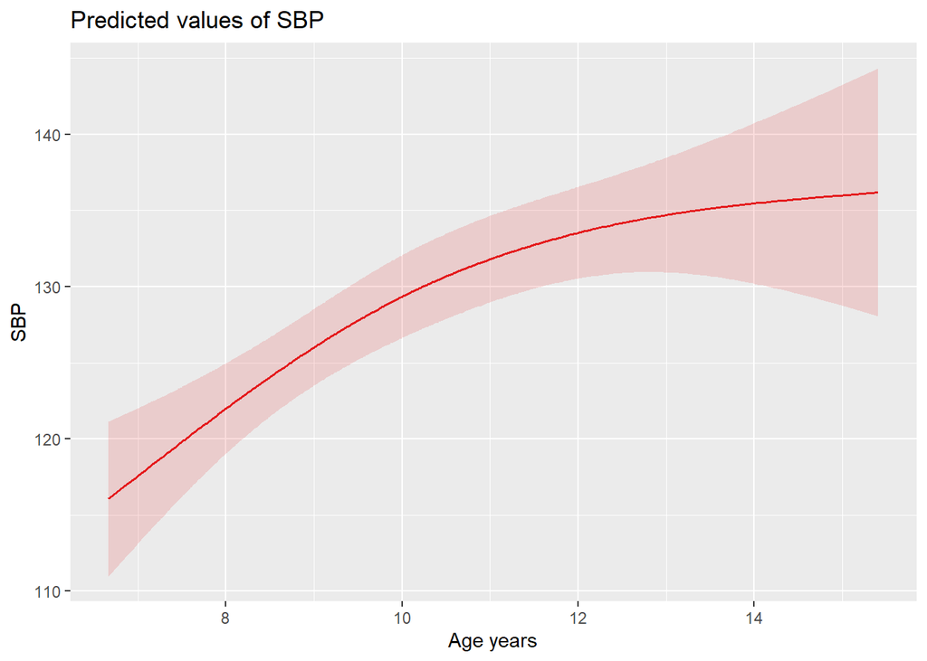

```r
plot_model(mod_healthy, type="pred", terms=c("Age_years[all]"), show.data=F)
```

#####check mod assumptions

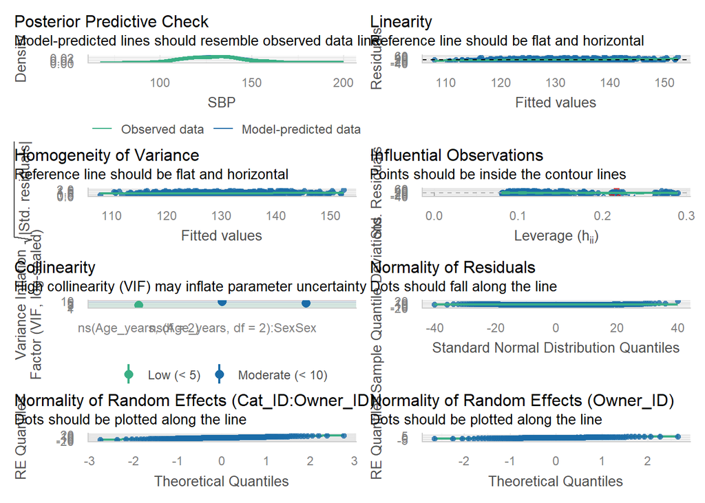

```r
check4<-check_model(mod_healthy)
print(check4)
```

```r
check_collinearity(mod_healthy)
```

```
## # Check for Multicollinearity
##
## Low Correlation
##
##                   Term  VIF   VIF 95% CI adj. VIF Tolerance Tolerance 95% CI
##  ns(Age_years, df = 2) 2.73 [2.43, 3.08]     1.65      0.37     [0.32, 0.41]
##
## Moderate Correlation
##
##                       Term  VIF   VIF 95% CI adj. VIF Tolerance
##                        Sex 5.00 [4.40, 5.71]     2.24      0.20
##  ns(Age_years, df = 2):Sex 8.67 [7.57, 9.96]     2.95      0.12
##  Tolerance 95% CI
##      [0.18, 0.23]
##      [0.10, 0.13]
```

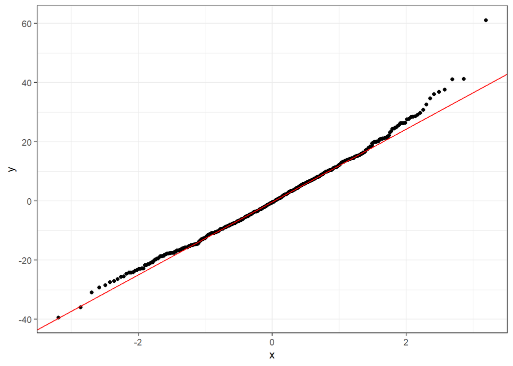

```r
# Extract residuals
res <- residuals(mod_healthy)
#qq plot of resids
ggplot(data.frame(res), aes(sample = res)) +
  stat_qq() +
  stat_qq_line(color = "red") +
  theme_bw()
```

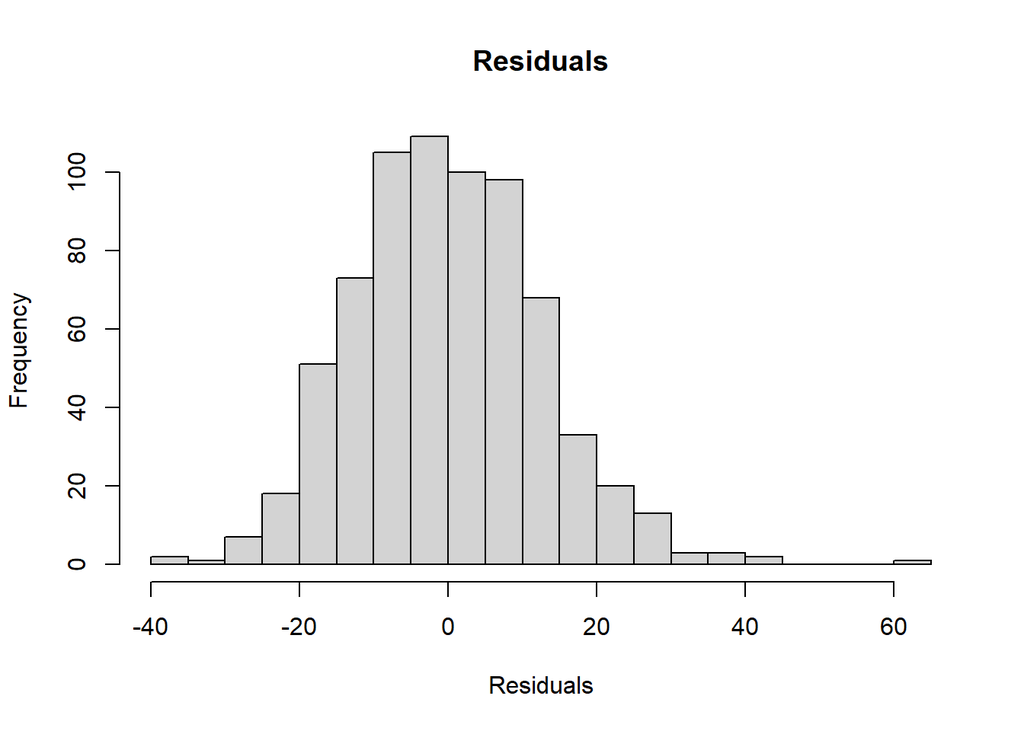

```r
#histogram of resids
hist(res, breaks = 20, main = "Residuals", xlab = "Residuals")
```

####subet by “healthy over entire study” interactions

```r
data_healthyoverstudy<-Metadata_SBP2%>%
  filter(Overall_health_status=="Healthy")


mod_healthyoverstudy<-lmer(SBP ~ ns(Age_years, df=2) + Sex + ns(Age_years, df=2):Sex +(1|Cat_ID), data_healthyoverstudy)

tab_model(mod_healthyoverstudy)
```

|  | SBP |  |  |
| --- | --- | --- | --- |
| Predictors | Estimates | CI | p |
| (Intercept) | 119.44 | 113.25 – 125.63 | **<0.001** |
| Age years [1st degree] | 24.80 | 11.46 – 38.15 | **<0.001** |
| Age years [2nd degree] | 16.11 | 1.95 – 30.27 | **0.026** |
| Sex [Male] | 5.58 | -4.06 – 15.22 | 0.255 |
| Age years [1st degree] × Sex [Male] | -4.94 | -26.16 – 16.29 | 0.648 |
| Age years [2nd degree] × Sex [Male] | -1.55 | -24.56 – 21.46 | 0.895 |
| Random Effects |  |  |  |
| σ<sup>2</sup> | 169.01 |  |  |
| τ<sub>00</sub> <sub>Cat_ID</sub> | 65.81 |  |  |
| ICC | 0.28 |  |  |
| N <sub>Cat_ID</sub> | 69 |  |  |
| Observations | 276 |  |  |
| Marginal R<sup>2</sup> / Conditional R<sup>2</sup> | 0.090 / 0.345 |  |  |

```
## Model contains splines or polynomial terms. Consider using
##   `terms="Age_years [all]"` to get smooth plots. See also package-vignette
##   'Adjusted Predictions at Specific Values'.
```

```
## Some of the focal terms are of type `character`. This may lead to
##   unexpected results. It is recommended to convert these variables to
##   factors before fitting the model.
##   The following variables are of type character: `Sex`
```

```
## Model contains splines or polynomial terms. Consider using `terms="Sex
##   [all]"` to get smooth plots. See also package-vignette 'Adjusted
##   Predictions at Specific Values'.
```

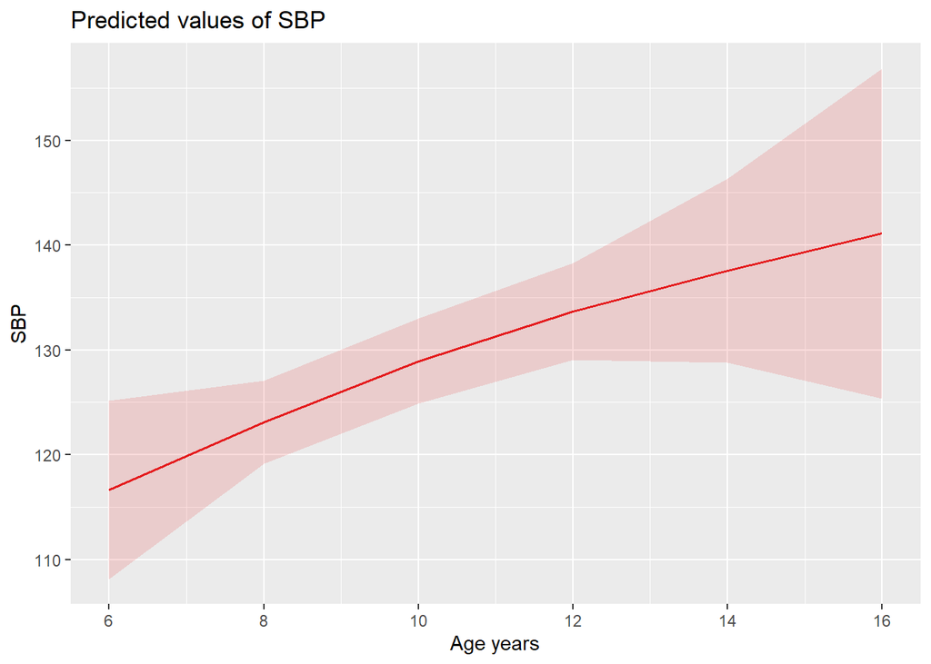

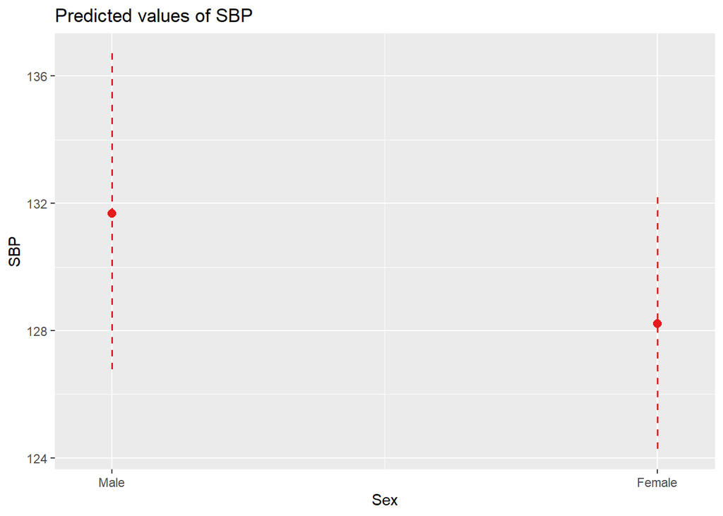

```r
plot_model(mod_healthyoverstudy, type="pred")
```

```r
#interactions
mod_int<-lmer(SBP ~ ns(Age_years, df=2) + Sex + ns(Age_years, df=2):Sex + Overall_health_status + ns(Age_years, df=2):Overall_health_status+ (1|Owner_ID/Cat_ID), Metadata_SBP2)

tab_model(mod_int)
```

|  | SBP |  |  |
| --- | --- | --- | --- |
| Predictors | Estimates | CI | p |
| (Intercept) | 116.26 | 109.72 – 122.79 | **<0.001** |
| Age years [1st degree] | 27.80 | 14.01 – 41.59 | **<0.001** |
| Age years [2nd degree] | 8.45 | -9.79 – 26.69 | 0.364 |
| Sex [Male] | 9.41 | 2.61 – 16.21 | **0.007** |
| Overall health status [Not_Healthy] | -1.34 | -8.62 – 5.94 | 0.719 |
| Age years [1st degree] × Sex [Male] | 0.01 | -13.60 – 13.62 | 0.999 |
| Age years [2nd degree] × Sex [Male] | 22.14 | 10.68 – 33.60 | **<0.001** |
| Age years [1st degree] × Overall health status [Not_Healthy] | 20.77 | 5.51 – 36.03 | **0.008** |
| Age years [2nd degree] × Overall health status [Not_Healthy] | 21.81 | 3.09 – 40.54 | **0.022** |
| Random Effects |  |  |  |
| σ<sup>2</sup> | 215.34 |  |  |
| τ<sub>00</sub> <sub>Cat_ID:Owner_ID</sub> | 107.05 |  |  |
| τ<sub>00</sub> <sub>Owner_ID</sub> | 27.65 |  |  |
| ICC | 0.38 |  |  |
| N <sub>Cat_ID</sub> | 203 |  |  |
| N <sub>Owner_ID</sub> | 146 |  |  |
| Observations | 1116 |  |  |
| Marginal R<sup>2</sup> / Conditional R<sup>2</sup> | 0.250 / 0.538 |  |  |